# Skript zur Messung der Intuitivität von Aufgabenannotationen.

Inhalte von Myriel Fichtner, Urs Fichtner, und Stefan Jablonski. Erstellung dieses Skripts mit wesentlicher Unterstützung von Matthias Sehlbrede.

2022-06-10 (Erstfassung)

# Datenimport

Die Rohdaten wurden manuell in ihren Namen angepasst und die Umlaute entfernt.

```r
df <- read.csv2("Datensatz_Longformat.csv")
names(df)
```

```
##  [1] "FBNUMMER"            "Erfahrung"           "Praef_Anleitung"
##  [4] "ALTER_B"             "Geschlecht"          "Abschluss"
##  [7] "Aufgabenstellung"    "Repraesentation"     "Effektivitaet"
## [10] "Mentale_Anstrengung" "Zufriedenheit"       "Interpretation"
## [13] "Paarvgl"             "Paarvgl_typ"
```

# Datenbearbeitung

Es wurden nur die numerischen Variablen “Abschluss” und “Expertise” faktorisiert, damit R diese auch als kategoriale Variable in den Analysen erkennt. Für die Expertise waren die Stufen bekannt, für Abschluss nicht, daher erhält der Faktor Abschluss keine spezifischen Bezeichnungen mehr für die Stufen, während Experte (0 = ohne Vorwissen und 1 = mit Voriwssen) wurde.

```r
df$Abschluss <- as.factor(df$Abschluss)
df$Erfahrung <- factor(df$Erfahrung,
                     levels = c(0, 1),
                     labels = c("ohne Vorwissen",
                                "Mit Vorwissen"))
```

# Methode / Vorgehen

Für alle Modelle aus den Fragestellungen 1 und 2 wurden *linear gemischte Modelle* (Linear-Mixed-Models, LMM) berechnet. Dazu wurde das R-Paket lme4 genutzt. Die Freiheitsgrade für die Signifikanztestung wurden mittels der Satterthwaite Methode, implementiert im R Paket lmerTest bestimmt. Da es sich hierbei um Messwiederholungen handelt, wurde auf Gruppenebene (Level 2) die Personen-ID (FBNUMMER) als Clustervariable genutzt. Auf Level 1 liegen die jeweiligen Werte der abhängigen Variable. Als Prädiktor für alle Modelle wird die *Repräsentation* (Faktor mit 3 Stufen) genutzt. Weitere Prädiktoren sind die *Erfahrung* (Faktor mit 2 Stufen), der *Abschluss* (Faktor mit 5 Stufen) sowie der *Aufgabenstellung* (Faktor mit 3 Stufen). Es werden für alle Prädiktoren nur feste Effekte (fixed Effects) bestimmt. Als Maß der Modellgüte wird das marginale R² (umfasst nur den Anteil erklärter Varianz der festen Effekte) nach Nakagawa, Johnson & Schielzeth (Nakagawa et al., 2017) über das Paket MuMIn bestimmt.

Da es sich bei den Prädiktoren um mehrstufige kategoriale Prädiktoren handelte, wurde im Nachgang immer noch ein *paarweiser Vergleich* durchgeführt. Diese paarweisen Vergleiche wurden mittels des Pakets emmeans bestimmt, in dem die Tukey-Methode zur Korrektur für multiples Testen angewendet wird. Zusätzlich fand eine *Visualisierung* der paarweisen Vergleiche auf Basis der in den Modell bestimmten Gruppenmittelwerte statt. In der visualisierung werden jeweils die Gruppenmittelwerte mit ihrem zugehörigen 95%-Konfidenzintervall präsentiert.

# Fragestellungen

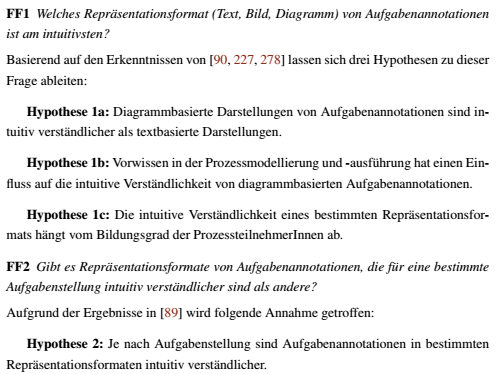

Abbildung. Screenshot der Fragestellungen und Hypothesen aus der Dissertation von Myriel Fichtner.

# Modellbezeichnungen:

- Basismodell: Dies ist nur das Analysemodell in dem nur die abhängige Variable und die Repäsentation als Prädiktor vorhanden sind.
- Haupteffektmodell: Bezeichnet ein Modell, in dem die abhängige Variable, die Repräsentation sowie ein weiterer relevanter Prädiktoren drin sind. Dabei hat der weitere Prädiktor keinerlei Interaktionen mit einer anderen Variable im Modell. Sollte eine 3-frach-Interkation vorliegen, bezeichnet Haupteffektmodell das Modell in dem es keine 3-fach-Interaktionen gibt und der 3. Faktor (z.B. Erfahrung) keine Interaktionen aufweist.
- Gesamtmodell: Bezeichnet das vollständige, saturierte Modell. In diesem Modell dürfen alle Prädiktoren miteinander interagieren. Für die Fragestellungen 1b, 1c und 2 umfasst dies Modelle mit je 2-fach-Interaktion.

# Auswertungen 1 & 2

Die Auswertungen für die Fragestellungen 1 und 2 sind nach der jeweiligen abhängigen Variablen (Zufriedenheit, Effektivität, Mentale Anstrengung) gegliedert. Für jede abhängige Variable finden sich die Ergebnisse zu den einzelnen Fragestellungen in den einzelnen Reitern (Tabs).

## Zufriedenheit

### Modellspezifikationen

```r
# Basismodell (Frage 1a)
quesi_1a <- lmer(Zufriedenheit ~ Repraesentation + (1 | FBNUMMER), data = df)
# mit Experten (Fragestellung 1b)
.quesi_1b <- lmer(Zufriedenheit ~ Repraesentation + Erfahrung + (1 | FBNUMMER), data = df)
quesi_1b <- lmer(Zufriedenheit ~ Repraesentation * Erfahrung + (1 | FBNUMMER), data = df)
# mit Abschluss (Fragestellung 1c)
.quesi_1c <- lmer(Zufriedenheit ~ Repraesentation + Abschluss + (1 | FBNUMMER), data = df)
quesi_1c <- lmer(Zufriedenheit ~ Repraesentation * Abschluss + (1 | FBNUMMER), data = df)
# mit Aufgabenstellung (Fragestellung 2)
.quesi_2 <- lmer(Zufriedenheit ~ Repraesentation + Aufgabenstellung + (1 | FBNUMMER), data = df)
quesi_2 <- lmer(Zufriedenheit ~ Repraesentation * Aufgabenstellung + (1 | FBNUMMER), data = df)
# mit Aufgabenstellung & Experten (Fragestellung 2b)
# .quesi_2b <- lmer(Zufriedenheit ~ Repraesentation * Aufgabenstellung + Erfahrung + (1 | FBNUMMER), data = df)
# quesi_2b <- lmer(Zufriedenheit ~ Repraesentation * Aufgabenstellung * Erfahrung + (1 | FBNUMMER), data = df)
# mit Aufgabenstellung & Abschluss (Fragestellung 2c)
# .quesi_2c <- lmer(Zufriedenheit ~ Repraesentation * Aufgabenstellung + Abschluss + (1 | FBNUMMER), data = df)
# quesi_2c <- lmer(Zufriedenheit ~ Repraesentation * Aufgabenstellung * Abschluss + (1 | FBNUMMER), data = df)

# erklärte Varianzen
r2_1a <- MuMIn::r.squaredGLMM(quesi_1a)[[1]]
.r2_1b <- MuMIn::r.squaredGLMM(.quesi_1b)[[1]]
r2_1b <- MuMIn::r.squaredGLMM(quesi_1b)[[1]]
.r2_1c <- MuMIn::r.squaredGLMM(.quesi_1c)[[1]]
r2_1c <- MuMIn::r.squaredGLMM(quesi_1c)[[1]]
.r2_2 <- MuMIn::r.squaredGLMM(.quesi_2)[[1]]
r2_2 <- MuMIn::r.squaredGLMM(quesi_2)[[1]]
#.r2_2b <- MuMIn::r.squaredGLMM(.quesi_2b)[[1]]
#r2_2b <- MuMIn::r.squaredGLMM(quesi_2b)[[1]]
#.r2_2c <- MuMIn::r.squaredGLMM(.quesi_2c)[[1]]
#r2_2c <- MuMIn::r.squaredGLMM(quesi_2c)[[1]]
```

### Outputs

#### 1a)

Ergebnis:

- Signifikanter Zusammenhang zwischen Repräsentation und Zufriedenheit
- Textuelle Repräsentation signifikant geringere Zufriedenheits-Werte als andere beiden Repräsentationen
- Bildgestützte und diagrammbasierte Repräsentationen zeigen untereinander keine signifikanten Unterschiede mehr.

Anteil erklärter Varianz (R²):

- Basismodell: 0.098

##### Basismodell

```r
anova(quesi_1a)
```

```
## Type III Analysis of Variance Table with Satterthwaite's method
##                 Sum Sq Mean Sq NumDF DenDF F value    Pr(>F)
## Repraesentation 8.8083  4.4041     2    98  10.133 9.995e-05 ***
## ---
## Signif. codes:  0 '***' 0.001 '**' 0.01 '*' 0.05 '.' 0.1 ' ' 1
```

##### Paarweiser Vergleich

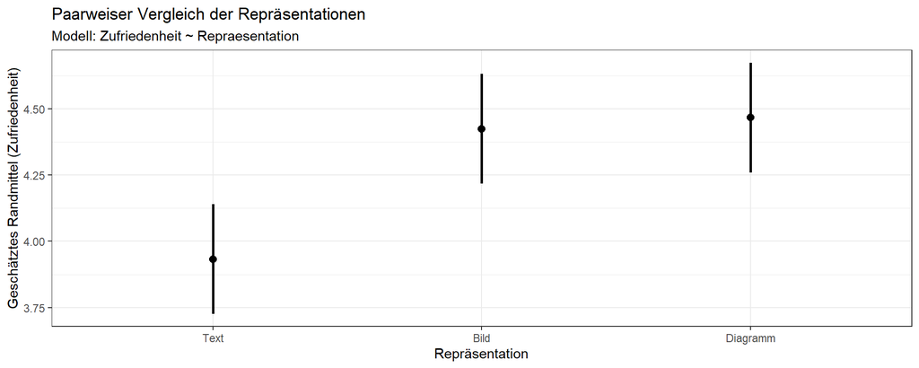

```r
representation_order <- c("Text", "Bild", "Diagramm")

emmeans(quesi_1a, specs = pairwise ~ Repraesentation)$emmeans %>% as.data.frame() %>%
    mutate(Repraesentation = factor(Repraesentation, levels = representation_order)) %>%
    ggplot(., aes(x = Repraesentation, y = emmean)) +
    geom_point(position = position_dodge(width = .2),
               size = 2.5) +
    geom_errorbar(aes(ymin = lower.CL, ymax = upper.CL),
                  width = 0, position = position_dodge(width = .2),
                  size = 1) +
    scale_color_manual(values = c("Text" = "gray80", "Bild" = "#00008B", "Diagramm" = "#808080")) +
    theme_bw() +
    theme(legend.position = "bottom") +
    labs(x = "Repräsentation",
         y = "Geschätztes Randmittel (Zufriedenheit)",
         title = "Paarweiser Vergleich der Repräsentationen",
         subtitle = "Modell: Zufriedenheit ~ Repraesentation")
```

*Anmerkung.* Darstellung der geschätzten Randmittel für Zufriedenheit für die Repräsentationen. Dargestellt werden Mittelwert mit dem 95%-Konfidenzintervall als Fehlerbalken.

```r
emmeans(quesi_1a, specs = pairwise ~ Repraesentation)
```

```
## $emmeans
##  Repraesentation emmean    SE  df lower.CL upper.CL
##  Bild              4.42 0.105 136     4.22     4.63
##  Diagramm          4.47 0.105 136     4.26     4.67
##  Text              3.93 0.105 136     3.73     4.14
##
## Degrees-of-freedom method: kenward-roger
## Confidence level used: 0.95
##
## $contrasts
##  contrast        estimate    SE df t.ratio p.value
##  Bild - Diagramm   -0.043 0.132 98  -0.326  0.9431
##  Bild - Text        0.491 0.132 98   3.725  0.0009
##  Diagramm - Text    0.534 0.132 98   4.052  0.0003
##
## Degrees-of-freedom method: kenward-roger
## P value adjustment: tukey method for comparing a family of 3 estimates
```

#### 1b)

Ergebnis:

- Keine signifikante Interaktion zwischen Erfahrung und Repräsentation für Zufriedenheit.
- Erfahrung hat auch alleine keinen signifikanten Haupteffekt.
- Textuelle Annotationen immer geringste Werte, unabhängig von der Erfahrung

Anteil erklärter Varianz (R²):

- Gesamtmodell: 0.103
- Haupteffektmodell ohne Interaktionen: 0.103
- Hinzunahme von Erfahrung: 0.005
- Hinzunahme Interaktion im Vergleich zum Haupteffektmodell: 1.5^{-4}

##### Modelle

###### Haupteffektmodell

```r
anova(.quesi_1b)
```

```
## Type III Analysis of Variance Table with Satterthwaite's method
##                 Sum Sq Mean Sq NumDF DenDF F value    Pr(>F)
## Repraesentation 8.8083  4.4041     2    98 10.1334 9.995e-05 ***
## Erfahrung       0.3131  0.3131     1    48  0.7205    0.4002
## ---
## Signif. codes:  0 '***' 0.001 '**' 0.01 '*' 0.05 '.' 0.1 ' ' 1
```

###### Gesamtmodell

```r
anova(quesi_1b)
```

```
## Type III Analysis of Variance Table with Satterthwaite's method
##                           Sum Sq Mean Sq NumDF DenDF F value    Pr(>F)
## Repraesentation           8.7172  4.3586     2    96  9.8485 0.0001287 ***
## Erfahrung                 0.3189  0.3189     1    48  0.7205 0.4002009
## Repraesentation:Erfahrung 0.1060  0.0530     2    96  0.1198 0.8872709
## ---
## Signif. codes:  0 '***' 0.001 '**' 0.01 '*' 0.05 '.' 0.1 ' ' 1
```

##### Paarweiser Vergleich

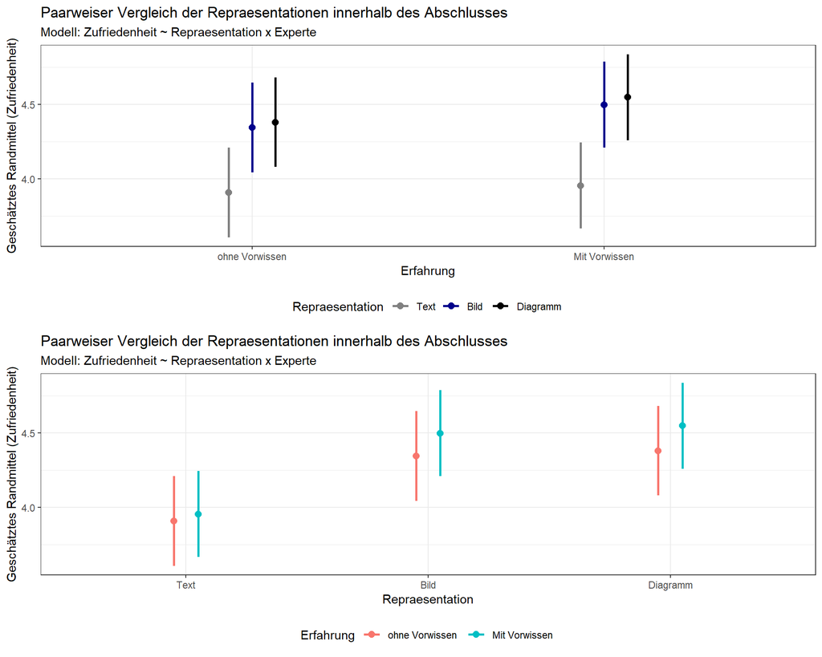

```r
representation_order <- c("Text", "Bild", "Diagramm")

plot_grid(
  emmeans(quesi_1b, specs = pairwise ~ Repraesentation * Erfahrung)$emmeans %>% as.data.frame() %>%
    mutate(Repraesentation = factor(Repraesentation, levels = representation_order)) %>%
    ggplot(., aes(x = Erfahrung, y = emmean, color = Repraesentation)) +
    geom_point(position = position_dodge(width = .2),
               size = 2.5) +
    geom_errorbar(aes(ymin = lower.CL, ymax = upper.CL),
                  width = 0, position = position_dodge(width = .2),
                  size = 1) +
    scale_color_manual(values = c("Text" = "#808080", "Bild" = "#00008B", "Diagramm" = "#000000")) +
    theme_bw() +
    theme(legend.position = "bottom") +
    labs(x = "Erfahrung",
         y = "Geschätztes Randmittel (Zufriedenheit)",
         title = "Paarweiser Vergleich der Repraesentationen innerhalb des Abschlusses",
         subtitle = "Modell: Zufriedenheit ~ Repraesentation x Experte"),

   emmeans(quesi_1b, specs = pairwise ~ Repraesentation * Erfahrung)$emmeans %>% as.data.frame() %>%
    mutate(Repraesentation = factor(Repraesentation, levels = representation_order)) %>%
    ggplot(., aes(x = Repraesentation, y = emmean, color = Erfahrung)) +
    geom_point(position = position_dodge(width = .2),
               size = 2.5) +
    geom_errorbar(aes(ymin = lower.CL, ymax = upper.CL),
                  width = 0, position = position_dodge(width = .2),
                  size = 1) +
    theme_bw() +
    theme(legend.position = "bottom") +
    labs(x = "Repraesentation",
         y = "Geschätztes Randmittel (Zufriedenheit)",
         title = "Paarweiser Vergleich der Repraesentationen innerhalb des Abschlusses",
         subtitle = "Modell: Zufriedenheit ~ Repraesentation x Experte"),
  ncol = 1
)
```

###### Repraesentation nach Erfahrung

```r
emmeans(quesi_1b, specs = pairwise ~ Repraesentation | Erfahrung)
```

```
## $emmeans
## Erfahrung = ohne Vorwissen:
##  Repraesentation emmean    SE  df lower.CL upper.CL
##  Bild              4.34 0.152 133     4.04     4.65
##  Diagramm          4.38 0.152 133     4.08     4.68
##  Text              3.91 0.152 133     3.61     4.21
##
## Erfahrung = Mit Vorwissen:
##  Repraesentation emmean    SE  df lower.CL upper.CL
##  Bild              4.50 0.146 133     4.21     4.79
##  Diagramm          4.55 0.146 133     4.26     4.84
##  Text              3.96 0.146 133     3.67     4.24
##
## Degrees-of-freedom method: kenward-roger
## Confidence level used: 0.95
##
## $contrasts
## Erfahrung = ohne Vorwissen:
##  contrast        estimate    SE df t.ratio p.value
##  Bild - Diagramm  -0.0354 0.192 96  -0.184  0.9814
##  Bild - Text       0.4367 0.192 96   2.274  0.0644
##  Diagramm - Text   0.4721 0.192 96   2.458  0.0413
##
## Erfahrung = Mit Vorwissen:
##  contrast        estimate    SE df t.ratio p.value
##  Bild - Diagramm  -0.0500 0.185 96  -0.271  0.9603
##  Bild - Text       0.5415 0.185 96   2.935  0.0115
##  Diagramm - Text   0.5915 0.185 96   3.206  0.0052
##
## Degrees-of-freedom method: kenward-roger
## P value adjustment: tukey method for comparing a family of 3 estimates
```

###### Erfahrung nach Repraesentation

```r
emmeans(quesi_1b, specs = pairwise ~ Erfahrung | Repraesentation)
```

```
## $emmeans
## Repraesentation = Bild:
##  Erfahrung      emmean    SE  df lower.CL upper.CL
##  ohne Vorwissen   4.34 0.152 133     4.04     4.65
##  Mit Vorwissen    4.50 0.146 133     4.21     4.79
##
## Repraesentation = Diagramm:
##  Erfahrung      emmean    SE  df lower.CL upper.CL
##  ohne Vorwissen   4.38 0.152 133     4.08     4.68
##  Mit Vorwissen    4.55 0.146 133     4.26     4.84
##
## Repraesentation = Text:
##  Erfahrung      emmean    SE  df lower.CL upper.CL
##  ohne Vorwissen   3.91 0.152 133     3.61     4.21
##  Mit Vorwissen    3.96 0.146 133     3.67     4.24
##
## Degrees-of-freedom method: kenward-roger
## Confidence level used: 0.95
##
## $contrasts
## Repraesentation = Bild:
##  contrast                       estimate    SE  df t.ratio p.value
##  ohne Vorwissen - Mit Vorwissen  -0.1523 0.211 133  -0.723  0.4709
##
## Repraesentation = Diagramm:
##  contrast                       estimate    SE  df t.ratio p.value
##  ohne Vorwissen - Mit Vorwissen  -0.1669 0.211 133  -0.792  0.4296
##
## Repraesentation = Text:
##  contrast                       estimate    SE  df t.ratio p.value
##  ohne Vorwissen - Mit Vorwissen  -0.0475 0.211 133  -0.225  0.8221
##
## Degrees-of-freedom method: kenward-roger
```

#### 1c)

Ergebnis

- Keine signifikante Interaktion zwischen Abschluss und Repräsentation für Zufriedenheit.
- Abschluss zeigt keinerlei signifikanten Haupteffekt.
- Paarweiser Vergleich zeigt keine systematischen Effekte zwischen den Abschlüssen, außer, dass textuelle Annotationen immer etwas geringere Werte bzgl. Zufriedenheit hatte.

Anteil erklärter Varianz (R²):

- Gesamtmodell: 0.128
- Haupteffektmodell ohne Interaktionen: 0.105
- Hinzunahme von Abschluss: 0.007
- Hinzunahme Interaktion im Vergleich zum Haupteffektmodell: 0.02283

##### Modelle

###### Haupteffektmodell

```r
anova(.quesi_1c)
```

```
## Type III Analysis of Variance Table with Satterthwaite's method
##                 Sum Sq Mean Sq NumDF DenDF F value    Pr(>F)
## Repraesentation 8.8083  4.4041     2    98 10.1334 9.995e-05 ***
## Abschluss       0.5274  0.1319     4    45  0.3034    0.8742
## ---
## Signif. codes:  0 '***' 0.001 '**' 0.01 '*' 0.05 '.' 0.1 ' ' 1
```

###### Gesamtmodell

```r
anova(quesi_1c)
```

```
## Type III Analysis of Variance Table with Satterthwaite's method
##                           Sum Sq Mean Sq NumDF DenDF F value Pr(>F)
## Repraesentation           4.2910 2.14549     2    90  4.8274 0.0102 *
## Abschluss                 0.5393 0.13483     4    45  0.3034 0.8742
## Repraesentation:Abschluss 2.5930 0.32412     8    90  0.7293 0.6653
## ---
## Signif. codes:  0 '***' 0.001 '**' 0.01 '*' 0.05 '.' 0.1 ' ' 1
```

##### Paarweiser Vergleich

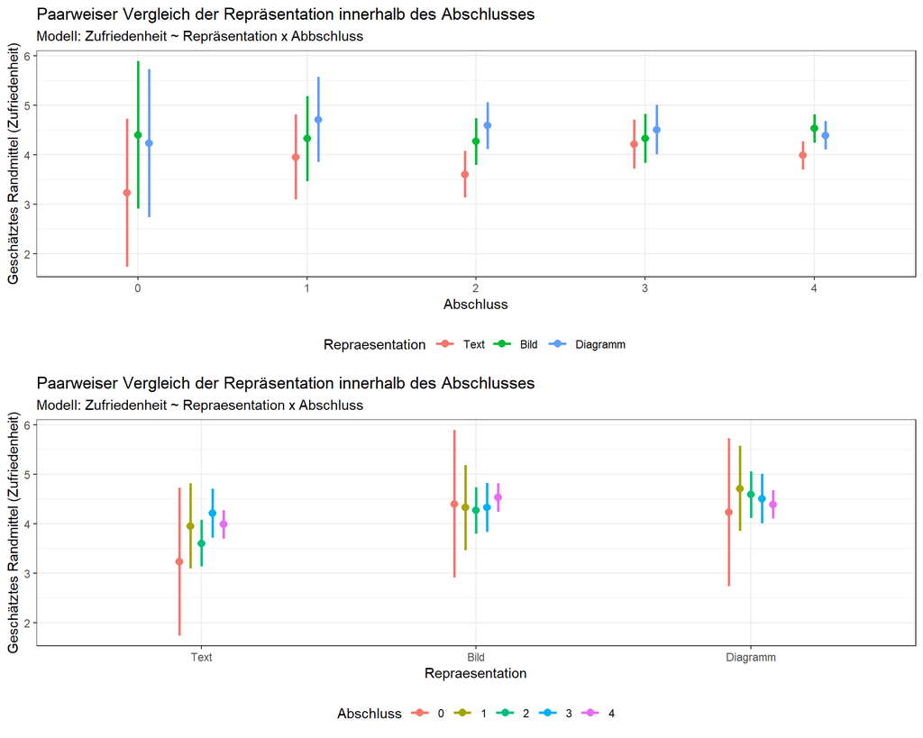

```r
representation_order <- c("Text", "Bild", "Diagramm")

plot_grid(
  emmeans(quesi_1c, specs = pairwise ~ Repraesentation * Abschluss)$emmeans %>% as.data.frame() %>%
    mutate(Repraesentation = factor(Repraesentation, levels = representation_order)) %>%
    ggplot(., aes(x = Abschluss, y = emmean, color = Repraesentation)) +
    geom_point(position = position_dodge(width = .2),
               size = 2.5) +
    geom_errorbar(aes(ymin = lower.CL, ymax = upper.CL),
                  width = 0, position = position_dodge(width = .2),
                  size = 1) +
    theme_bw() +
    theme(legend.position = "bottom") +
    labs(x = "Abschluss",
         y = "Geschätztes Randmittel (Zufriedenheit)",
         title = "Paarweiser Vergleich der Repräsentation innerhalb des Abschlusses",
         subtitle = "Modell: Zufriedenheit ~ Repräsentation x Abbschluss"),

   emmeans(quesi_1c, specs = pairwise ~ Repraesentation * Abschluss)$emmeans %>% as.data.frame() %>%
    mutate(Repraesentation = factor(Repraesentation, levels = representation_order)) %>%
    ggplot(., aes(x = Repraesentation, y = emmean, color = Abschluss)) +
    geom_point(position = position_dodge(width = .2),
               size = 2.5) +
    geom_errorbar(aes(ymin = lower.CL, ymax = upper.CL),
                  width = 0, position = position_dodge(width = .2),
                  size = 1) +
    theme_bw() +
    theme(legend.position = "bottom") +
    labs(x = "Repraesentation",
         y = "Geschätztes Randmittel (Zufriedenheit)",
         title = "Paarweiser Vergleich der Repräsentation innerhalb des Abschlusses",
         subtitle = "Modell: Zufriedenheit ~ Repraesentation x Abschluss"),
  ncol = 1
)
```

*Anmerkung.* Darstellung der geschätzten Randmittel für Zufriedenheit für die Repräsentationen getrennt nach Abschluss (oben) und einmal für den Abschluss getrennt nach Repräsentation (unten). Dargestellt werden Mittelwert mit dem 95%-Konfidenzintervall als Fehlerbalken.

###### Repraesentation nach Abschluss

```r
emmeans(quesi_1c, specs = pairwise ~ Repraesentation | Abschluss)
```

```
## $emmeans
## Abschluss = 0:
##  Repraesentation emmean    SE  df lower.CL upper.CL
##  Bild              4.40 0.754 123     2.91     5.89
##  Diagramm          4.23 0.754 123     2.74     5.72
##  Text              3.23 0.754 123     1.74     4.72
##
## Abschluss = 1:
##  Repraesentation emmean    SE  df lower.CL upper.CL
##  Bild              4.32 0.436 123     3.46     5.19
##  Diagramm          4.71 0.436 123     3.85     5.57
##  Text              3.95 0.436 123     3.09     4.82
##
## Abschluss = 2:
##  Repraesentation emmean    SE  df lower.CL upper.CL
##  Bild              4.27 0.239 123     3.79     4.74
##  Diagramm          4.59 0.239 123     4.12     5.06
##  Text              3.60 0.239 123     3.13     4.07
##
## Abschluss = 3:
##  Repraesentation emmean    SE  df lower.CL upper.CL
##  Bild              4.33 0.251 123     3.83     4.82
##  Diagramm          4.51 0.251 123     4.01     5.00
##  Text              4.21 0.251 123     3.72     4.71
##
## Abschluss = 4:
##  Repraesentation emmean    SE  df lower.CL upper.CL
##  Bild              4.53 0.145 123     4.24     4.81
##  Diagramm          4.39 0.145 123     4.10     4.68
##  Text              3.99 0.145 123     3.70     4.27
##
## Degrees-of-freedom method: kenward-roger
## Confidence level used: 0.95
##
## $contrasts
## Abschluss = 0:
##  contrast        estimate    SE df t.ratio p.value
##  Bild - Diagramm    0.170 0.943 90   0.180  0.9822
##  Bild - Text        1.170 0.943 90   1.241  0.4324
##  Diagramm - Text    1.000 0.943 90   1.061  0.5409
```

[output cut: 12 more lines]

```
##
## Abschluss = 3:
##  contrast        estimate    SE df t.ratio p.value
##  Bild - Diagramm   -0.181 0.314 90  -0.576  0.8331
##  Bild - Text        0.112 0.314 90   0.357  0.9322
##  Diagramm - Text    0.293 0.314 90   0.933  0.6207
##
## Abschluss = 4:
##  contrast        estimate    SE df t.ratio p.value
##  Bild - Diagramm    0.137 0.181 90   0.753  0.7325
##  Bild - Text        0.541 0.181 90   2.984  0.0101
##  Diagramm - Text    0.405 0.181 90   2.231  0.0714
##
## Degrees-of-freedom method: kenward-roger
## P value adjustment: tukey method for comparing a family of 3 estimates
```

###### Abschluss nach Repraesentation

```r
emmeans(quesi_1c, specs = pairwise ~ Abschluss | Repraesentation)
```

```
## $emmeans
## Repraesentation = Bild:
##  Abschluss emmean    SE  df lower.CL upper.CL
##  0           4.40 0.754 123     2.91     5.89
##  1           4.32 0.436 123     3.46     5.19
##  2           4.27 0.239 123     3.79     4.74
##  3           4.33 0.251 123     3.83     4.82
##  4           4.53 0.145 123     4.24     4.81
##
## Repraesentation = Diagramm:
##  Abschluss emmean    SE  df lower.CL upper.CL
##  0           4.23 0.754 123     2.74     5.72
##  1           4.71 0.436 123     3.85     5.57
##  2           4.59 0.239 123     4.12     5.06
##  3           4.51 0.251 123     4.01     5.00
##  4           4.39 0.145 123     4.10     4.68
##
## Repraesentation = Text:
##  Abschluss emmean    SE  df lower.CL upper.CL
##  0           3.23 0.754 123     1.74     4.72
##  1           3.95 0.436 123     3.09     4.82
##  2           3.60 0.239 123     3.13     4.07
##  3           4.21 0.251 123     3.72     4.71
##  4           3.99 0.145 123     3.70     4.27
##
## Degrees-of-freedom method: kenward-roger
## Confidence level used: 0.95
##
## $contrasts
## Repraesentation = Bild:
##  contrast                estimate    SE  df t.ratio p.value
##  Abschluss0 - Abschluss1  0.07667 0.871 123   0.088  1.0000
##  Abschluss0 - Abschluss2  0.13400 0.791 123   0.169  0.9998
##  Abschluss0 - Abschluss3  0.07444 0.795 123   0.094  1.0000
##  Abschluss0 - Abschluss4 -0.12704 0.768 123  -0.165  0.9998
##  Abschluss1 - Abschluss2  0.05733 0.497 123   0.115  1.0000
##  Abschluss1 - Abschluss3 -0.00222 0.503 123  -0.004  1.0000
##  Abschluss1 - Abschluss4 -0.20370 0.459 123  -0.444  0.9919
##  Abschluss2 - Abschluss3 -0.05956 0.347 123  -0.172  0.9998
##  Abschluss2 - Abschluss4 -0.26104 0.279 123  -0.935  0.8829
```

[output cut: 15 more lines]

```
## Repraesentation = Text:
##  contrast                estimate    SE  df t.ratio p.value
##  Abschluss0 - Abschluss1 -0.72333 0.871 123  -0.830  0.9207
##  Abschluss0 - Abschluss2 -0.37100 0.791 123  -0.469  0.9900
##  Abschluss0 - Abschluss3 -0.98333 0.795 123  -1.237  0.7301
##  Abschluss0 - Abschluss4 -0.75556 0.768 123  -0.983  0.8623
##  Abschluss1 - Abschluss2  0.35233 0.497 123   0.709  0.9540
##  Abschluss1 - Abschluss3 -0.26000 0.503 123  -0.517  0.9855
##  Abschluss1 - Abschluss4 -0.03222 0.459 123  -0.070  1.0000
##  Abschluss2 - Abschluss3 -0.61233 0.347 123  -1.766  0.3978
##  Abschluss2 - Abschluss4 -0.38456 0.279 123  -1.377  0.6435
##  Abschluss3 - Abschluss4  0.22778 0.290 123   0.784  0.9347
##
## Degrees-of-freedom method: kenward-roger
## P value adjustment: tukey method for comparing a family of 5 estimates
```

#### 2)

Ergebnis:

- Es gab einen signifikante Interaktion zwischen der Aufgabenstellung und der Repräsentation.
- Haupteffekt vom Aufgabenstellung ebenfalls signfikant.
- Stapelaufgabe erzielt als textuelle Annotation die geringsten Werte, während sie in den anderen Bedingungen vergleichbar ist. In der bildbasierten Version auch (deskriptiv) höhere Werte als die Platzierungsaufgabe.

Anteil erklärter Varianz (R²):

##### Modelle

###### Haupteffektmodell

```r
anova(.quesi_2)
```

```
## Type III Analysis of Variance Table with Satterthwaite's method
##                   Sum Sq Mean Sq NumDF  DenDF F value    Pr(>F)
## Repraesentation   8.6272  4.3136     2 96.000  13.573 6.439e-06 ***
## Aufgabenstellung 11.8572  5.9286     2 96.511  18.655 1.414e-07 ***
## ---
## Signif. codes:  0 '***' 0.001 '**' 0.01 '*' 0.05 '.' 0.1 ' ' 1
```

###### Gesamtmodell

```r
anova(quesi_2)
```

```
## Type III Analysis of Variance Table with Satterthwaite's method
##                                   Sum Sq Mean Sq NumDF   DenDF F value
## Repraesentation                   7.8950  3.9475     2  91.912 13.5681
## Aufgabenstellung                 11.4943  5.7471     2  92.586 19.7537
## Repraesentation:Aufgabenstellung  9.8793  2.4698     4 127.620  8.4891
##                                     Pr(>F)
## Repraesentation                  6.868e-06 ***
## Aufgabenstellung                 7.167e-08 ***
## Repraesentation:Aufgabenstellung 4.176e-06 ***
## ---
## Signif. codes:  0 '***' 0.001 '**' 0.01 '*' 0.05 '.' 0.1 ' ' 1
```

##### Paarweiser Vergleich

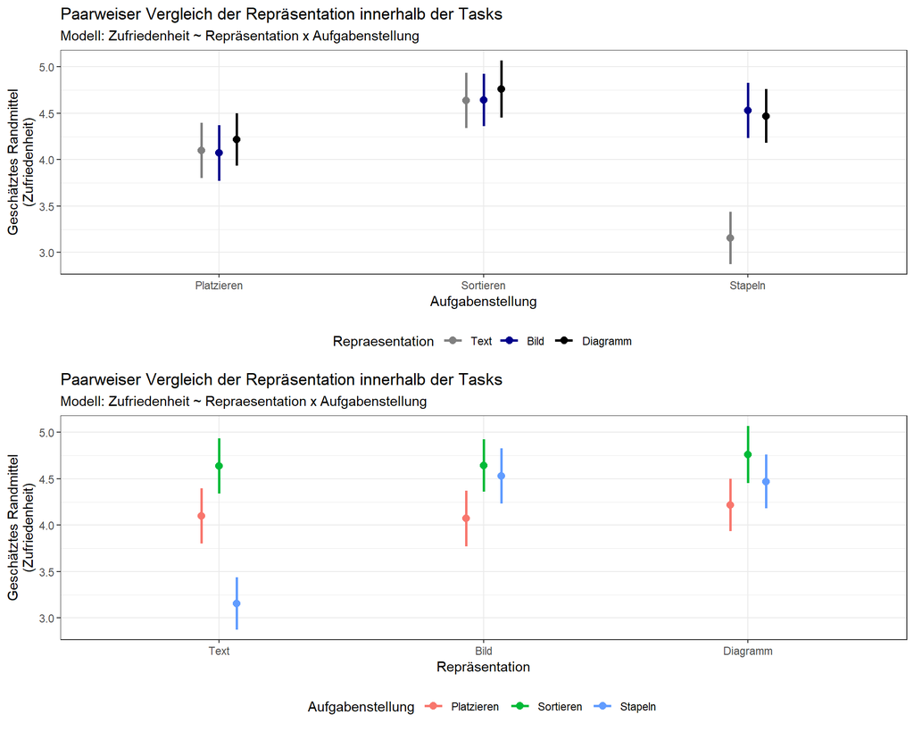

```r
representation_order <- c("Text", "Bild", "Diagramm")

plot_grid(
  emmeans(quesi_2, specs = pairwise ~ Repraesentation * Aufgabenstellung)$emmeans %>% as.data.frame() %>%
    mutate(Repraesentation = factor(Repraesentation, levels = representation_order)) %>%
    ggplot(., aes(x = Aufgabenstellung, y = emmean, color = Repraesentation)) +
    geom_point(position = position_dodge(width = .2),
               size = 2.5) +
    geom_errorbar(aes(ymin = lower.CL, ymax = upper.CL),
                  width = 0, position = position_dodge(width = .2),
                  size = 1) +
    scale_color_manual(values = c("Text" = "#808080", "Bild" = "#00008B", "Diagramm" = "#000000")) +
    theme_bw() +
    theme(legend.position = "bottom") +
    labs(x = "Aufgabenstellung",
         y = "Geschätztes Randmittel\n(Zufriedenheit)",
         title = "Paarweiser Vergleich der Repräsentation innerhalb der Tasks",
         subtitle = "Modell: Zufriedenheit ~ Repräsentation x Aufgabenstellung"),

  emmeans(quesi_2, specs = pairwise ~ Repraesentation * Aufgabenstellung)$emmeans %>% as.data.frame() %>%
    mutate(Repraesentation = factor(Repraesentation, levels = representation_order)) %>%
    ggplot(., aes(x = Repraesentation, y = emmean, color = Aufgabenstellung)) +
    geom_point(position = position_dodge(width = .2),
               size = 2.5) +
    geom_errorbar(aes(ymin = lower.CL, ymax = upper.CL),
                  width = 0, position = position_dodge(width = .2),
                  size = 1) +
    theme_bw() +
    theme(legend.position = "bottom") +
    labs(x = "Repräsentation",
         y = "Geschätztes Randmittel\n(Zufriedenheit)",
         title = "Paarweiser Vergleich der Repräsentation innerhalb der Tasks",
         subtitle = "Modell: Zufriedenheit ~ Repraesentation x Aufgabenstellung"),
  ncol = 1
)
```

```r
emmeans(quesi_2, specs = pairwise ~ Repraesentation | Aufgabenstellung)
```

```
## $emmeans
## Aufgabenstellung = Platzieren:
##  Repraesentation emmean    SE  df lower.CL upper.CL
##  Bild              4.07 0.151 141     3.77     4.37
##  Diagramm          4.22 0.143 140     3.93     4.50
##  Text              4.10 0.151 141     3.80     4.40
##
## Aufgabenstellung = Sortieren:
##  Repraesentation emmean    SE  df lower.CL upper.CL
##  Bild              4.64 0.143 141     4.36     4.92
##  Diagramm          4.76 0.156 141     4.45     5.07
##  Text              4.64 0.151 141     4.34     4.94
##
## Aufgabenstellung = Stapeln:
##  Repraesentation emmean    SE  df lower.CL upper.CL
##  Bild              4.53 0.151 141     4.23     4.83
##  Diagramm          4.47 0.147 141     4.18     4.76
##  Text              3.16 0.143 140     2.87     3.44
##
## Degrees-of-freedom method: kenward-roger
## Confidence level used: 0.95
##
## $contrasts
## Aufgabenstellung = Platzieren:
##  contrast        estimate    SE  df t.ratio p.value
##  Bild - Diagramm  -0.1445 0.207 140  -0.698  0.7651
##  Bild - Text      -0.0264 0.213 140  -0.124  0.9915
##  Diagramm - Text   0.1181 0.207 140   0.571  0.8356
##
## Aufgabenstellung = Sortieren:
##  contrast        estimate    SE  df t.ratio p.value
##  Bild - Diagramm  -0.1200 0.210 140  -0.571  0.8359
##  Bild - Text       0.0027 0.207 140   0.013  0.9999
##  Diagramm - Text   0.1227 0.216 140   0.567  0.8376
##
## Aufgabenstellung = Stapeln:
##  contrast        estimate    SE  df t.ratio p.value
##  Bild - Diagramm   0.0589 0.209 140   0.281  0.9573
##  Bild - Text       1.3732 0.205 139   6.686  <.0001
##  Diagramm - Text   1.3142 0.204 140   6.453  <.0001
##
## Degrees-of-freedom method: kenward-roger
## P value adjustment: tukey method for comparing a family of 3 estimates
```

```r
emmeans(quesi_2, specs = pairwise ~ Aufgabenstellung | Repraesentation)
```

```
## $emmeans
## Repraesentation = Bild:
##  Aufgabenstellung emmean    SE  df lower.CL upper.CL
##  Platzieren         4.07 0.151 141     3.77     4.37
##  Sortieren          4.64 0.143 141     4.36     4.92
##  Stapeln            4.53 0.151 141     4.23     4.83
##
## Repraesentation = Diagramm:
##  Aufgabenstellung emmean    SE  df lower.CL upper.CL
##  Platzieren         4.22 0.143 140     3.93     4.50
##  Sortieren          4.76 0.156 141     4.45     5.07
##  Stapeln            4.47 0.147 141     4.18     4.76
##
## Repraesentation = Text:
##  Aufgabenstellung emmean    SE  df lower.CL upper.CL
##  Platzieren         4.10 0.151 141     3.80     4.40
##  Sortieren          4.64 0.151 141     4.34     4.94
##  Stapeln            3.16 0.143 140     2.87     3.44
##
## Degrees-of-freedom method: kenward-roger
## Confidence level used: 0.95
##
## $contrasts
## Repraesentation = Bild:
##  contrast               estimate    SE  df t.ratio p.value
##  Platzieren - Sortieren   -0.568 0.207 140  -2.749  0.0185
##  Platzieren - Stapeln     -0.458 0.213 140  -2.152  0.0834
##  Sortieren - Stapeln       0.111 0.206 139   0.538  0.8529
##
## Repraesentation = Diagramm:
##  contrast               estimate    SE  df t.ratio p.value
##  Platzieren - Sortieren   -0.544 0.210 140  -2.587  0.0287
##  Platzieren - Stapeln     -0.254 0.204 140  -1.248  0.4274
##  Sortieren - Stapeln       0.290 0.213 140   1.361  0.3643
##
## Repraesentation = Text:
##  contrast               estimate    SE  df t.ratio p.value
##  Platzieren - Sortieren   -0.539 0.213 140  -2.537  0.0327
##  Platzieren - Stapeln      0.942 0.207 140   4.560  <.0001
##  Sortieren - Stapeln       1.481 0.207 140   7.161  <.0001
##
## Degrees-of-freedom method: kenward-roger
## P value adjustment: tukey method for comparing a family of 3 estimates
```

## Effektivität

### Modellspezifikationen

```r
# Basismodell (Frage 1a)
effekti_1a <- lmer(Effektivitaet ~ Repraesentation + (1 | FBNUMMER), data = df)
# mit Experten (Fragestellung 1b)
.effekti_1b <- lmer(Effektivitaet ~ Repraesentation + Erfahrung + (1 | FBNUMMER), data = df)
effekti_1b <- lmer(Effektivitaet ~ Repraesentation * Erfahrung + (1 | FBNUMMER), data = df)
# mit Abschluss (Fragestellung 1c)
.effekti_1c <- lmer(Effektivitaet ~ Repraesentation + Abschluss + (1 | FBNUMMER), data = df)
effekti_1c <- lmer(Effektivitaet ~ Repraesentation * Abschluss + (1 | FBNUMMER), data = df)
# mit Aufgabenstellung (Fragestellung 2)
.effekti_2 <- lmer(Effektivitaet ~ Repraesentation + Aufgabenstellung + (1 | FBNUMMER), data = df)
effekti_2 <- lmer(Effektivitaet ~ Repraesentation * Aufgabenstellung + (1 | FBNUMMER), data = df)
# mit Aufgabenstellung & Experten (Fragestellung 2b)
# .effekti_2b <- lmer(Effektivitaet ~ Repraesentation * Aufgabenstellung + Erfahrung + (1 | FBNUMMER), data = df)
# effekti_2b <- lmer(Effektivitaet ~ Repraesentation * Aufgabenstellung * Erfahrung + (1 | FBNUMMER), data = df)
# mit Aufgabenstellung & Abschluss (Fragestellung 2c)
# .effekti_2c <- lmer(Effektivitaet ~ Repraesentation * Aufgabenstellung + Abschluss + (1 | FBNUMMER), data = df)
# effekti_2c <- lmer(Effektivitaet ~ Repraesentation * Aufgabenstellung * Abschluss + (1 | FBNUMMER), data = df)

# erklärte Varianzen
r2_1a <- MuMIn::r.squaredGLMM(effekti_1a)[[1]]
.r2_1b <- MuMIn::r.squaredGLMM(.effekti_1b)[[1]]
r2_1b <- MuMIn::r.squaredGLMM(effekti_1b)[[1]]
.r2_1c <- MuMIn::r.squaredGLMM(.effekti_1c)[[1]]
r2_1c <- MuMIn::r.squaredGLMM(effekti_1c)[[1]]
.r2_2 <- MuMIn::r.squaredGLMM(.effekti_2)[[1]]
r2_2 <- MuMIn::r.squaredGLMM(effekti_2)[[1]]
#.r2_2b <- MuMIn::r.squaredGLMM(.effekti_2b)[[1]]
#r2_2b <- MuMIn::r.squaredGLMM(effekti_2b)[[1]]
#.r2_2c <- MuMIn::r.squaredGLMM(.effekti_2c)[[1]]
#r2_2c <- MuMIn::r.squaredGLMM(effekti_2c)[[1]]
```

### Outputs

#### 1a)

Ergebnis:

- Signifikanter Zusammenhang zwischen der Effektivität und der Repräsentation.
- Textuelle Annotation hat die geringsten Werte auf Effektivität.
- Bild- und Diagramm-Annotationen unterscheiden sich nicht signifikant voneinander.

Anteil erklärter Varianz (R²):

- Basismodell: 0.041

##### Basismodell

```r
anova(effekti_1a)
```

```
## Type III Analysis of Variance Table with Satterthwaite's method
##                 Sum Sq Mean Sq NumDF DenDF F value  Pr(>F)
## Repraesentation 1989.3  994.67     2    98  3.5649 0.03203 *
## ---
## Signif. codes:  0 '***' 0.001 '**' 0.01 '*' 0.05 '.' 0.1 ' ' 1
```

##### Paarweiser Vergleich

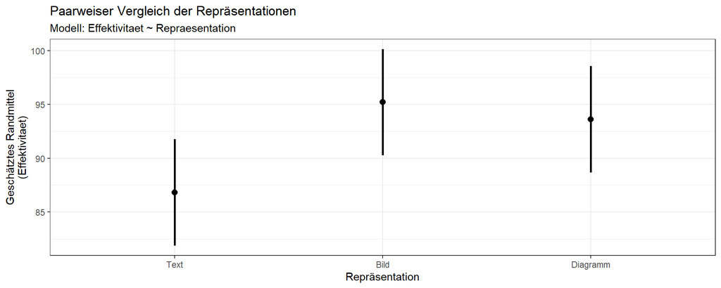

```r
representation_order <- c("Text", "Bild", "Diagramm")

emmeans(effekti_1a, specs = pairwise ~ Repraesentation)$emmeans %>% as.data.frame() %>%
  mutate(Repraesentation = factor(Repraesentation, levels = representation_order)) %>%
    ggplot(., aes(x = Repraesentation, y = emmean)) +
    geom_point(position = position_dodge(width = .2),
               size = 2.5) +
    geom_errorbar(aes(ymin = lower.CL, ymax = upper.CL),
                  width = 0, position = position_dodge(width = .2),
                  size = 1) +
    scale_color_manual(values = c("Text" = "#808080", "Bild" = "#00008B", "Diagramm" = "#000000")) +
    theme_bw() +
    theme(legend.position = "bottom") +
    labs(x = "Repräsentation",
         y = "Geschätztes Randmittel\n(Effektivitaet)",
         title = "Paarweiser Vergleich der Repräsentationen",
         subtitle = "Modell: Effektivitaet ~ Repraesentation")
```

*Anmerkung.* Darstellung der geschätzten Randmittel für Effektivität für die Repräsentationen. Dargestellt werden Mittelwert mit dem 95%-Konfidenzintervall als Fehlerbalken.

```r
emmeans(effekti_1a, specs = pairwise ~ Repraesentation)
```

```
## $emmeans
##  Repraesentation emmean  SE  df lower.CL upper.CL
##  Bild              95.2 2.5 144     90.3    100.1
##  Diagramm          93.6 2.5 144     88.7     98.5
##  Text              86.8 2.5 144     81.9     91.7
##
## Degrees-of-freedom method: kenward-roger
## Confidence level used: 0.95
##
## $contrasts
##  contrast        estimate   SE df t.ratio p.value
##  Bild - Diagramm      1.6 3.34 98   0.479  0.8814
##  Bild - Text          8.4 3.34 98   2.514  0.0358
##  Diagramm - Text      6.8 3.34 98   2.035  0.1092
##
## Degrees-of-freedom method: kenward-roger
## P value adjustment: tukey method for comparing a family of 3 estimates
```

#### 1b)

Ergebnis:

- Kein signifikanter Interaktionseffekt für die Erfahrung.
- Erfahrung hat auch keinen Haupteffekt auf die Effektivität

Anteil erklärter Varianz (R²):

- Gesamtmodell: 0.06
- Haupteffektmodell ohne Interaktionen: 0.057
- Hinzunahme von Erfahrung: 0.016
- Hinzunahme Interaktion im Vergleich zum Haupteffektmodell: 0.00247

##### Modelle

###### Haupteffektmodell

```r
anova(.effekti_1b)
```

```
## Type III Analysis of Variance Table with Satterthwaite's method
##                  Sum Sq Mean Sq NumDF DenDF F value  Pr(>F)
## Repraesentation 1989.33  994.67     2    98  3.5649 0.03203 *
## Erfahrung        606.76  606.76     1    48  2.1746 0.14684
## ---
## Signif. codes:  0 '***' 0.001 '**' 0.01 '*' 0.05 '.' 0.1 ' ' 1
```

###### Gesamtmodell

```r
anova(effekti_1b)
```

```
## Type III Analysis of Variance Table with Satterthwaite's method
##                            Sum Sq Mean Sq NumDF DenDF F value  Pr(>F)
## Repraesentation           2000.44 1000.22     2    96  3.5316 0.03312 *
## Erfahrung                  615.88  615.88     1    48  2.1746 0.14684
## Repraesentation:Erfahrung  155.11   77.56     2    96  0.2738 0.76105
## ---
## Signif. codes:  0 '***' 0.001 '**' 0.01 '*' 0.05 '.' 0.1 ' ' 1
```

##### Paarweiser Vergleich

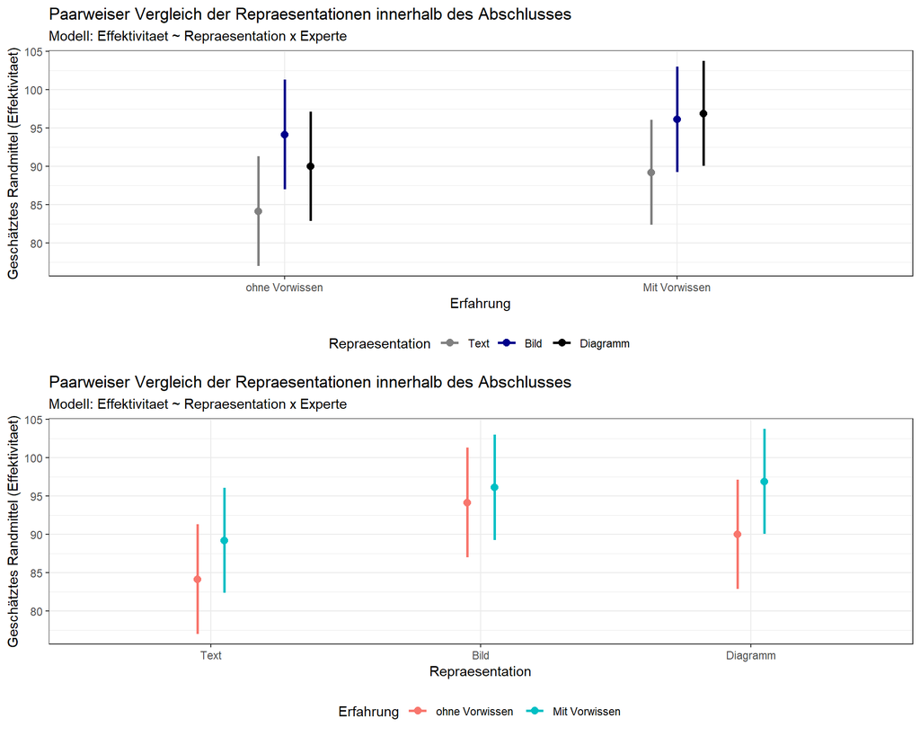

```r
representation_order <- c("Text", "Bild", "Diagramm")

plot_grid(
  emmeans(effekti_1b, specs = pairwise ~ Repraesentation * Erfahrung)$emmeans %>% as.data.frame() %>%
    mutate(Repraesentation = factor(Repraesentation, levels = representation_order)) %>%
    ggplot(., aes(x = Erfahrung, y = emmean, color = Repraesentation)) +
    geom_point(position = position_dodge(width = .2),
               size = 2.5) +
    geom_errorbar(aes(ymin = lower.CL, ymax = upper.CL),
                  width = 0, position = position_dodge(width = .2),
                  size = 1) +
    scale_color_manual(values = c("Text" = "#808080", "Bild" = "#00008B", "Diagramm" = "#000000")) +
    theme_bw() +
    theme(legend.position = "bottom") +
    labs(x = "Erfahrung",
         y = "Geschätztes Randmittel (Effektivitaet)",
         title = "Paarweiser Vergleich der Repraesentationen innerhalb des Abschlusses",
         subtitle = "Modell: Effektivitaet ~ Repraesentation x Experte"),

   emmeans(effekti_1b, specs = pairwise ~ Repraesentation * Erfahrung)$emmeans %>% as.data.frame() %>%
    mutate(Repraesentation = factor(Repraesentation, levels = representation_order)) %>%
    ggplot(., aes(x = Repraesentation, y = emmean, color = Erfahrung)) +
    geom_point(position = position_dodge(width = .2),
               size = 2.5) +
    geom_errorbar(aes(ymin = lower.CL, ymax = upper.CL),
                  width = 0, position = position_dodge(width = .2),
                  size = 1) +
    theme_bw() +
    theme(legend.position = "bottom") +
    labs(x = "Repraesentation",
         y = "Geschätztes Randmittel (Effektivitaet)",
         title = "Paarweiser Vergleich der Repraesentationen innerhalb des Abschlusses",
         subtitle = "Modell: Effektivitaet ~ Repraesentation x Experte"),
  ncol = 1
)
```

###### Repraesentation nach Erfahrung

```r
emmeans(effekti_1b, specs = pairwise ~ Repraesentation | Erfahrung)
```

```
## $emmeans
## Erfahrung = ohne Vorwissen:
##  Repraesentation emmean   SE  df lower.CL upper.CL
##  Bild              94.2 3.61 141     87.0    101.3
##  Diagramm          90.0 3.61 141     82.9     97.1
##  Text              84.2 3.61 141     77.0     91.3
##
## Erfahrung = Mit Vorwissen:
##  Repraesentation emmean   SE  df lower.CL upper.CL
##  Bild              96.2 3.47 141     89.3    103.0
##  Diagramm          96.9 3.47 141     90.1    103.8
##  Text              89.2 3.47 141     82.4     96.1
##
## Degrees-of-freedom method: kenward-roger
## Confidence level used: 0.95
##
## $contrasts
## Erfahrung = ohne Vorwissen:
##  contrast        estimate   SE df t.ratio p.value
##  Bild - Diagramm    4.167 4.86 96   0.858  0.6682
##  Bild - Text       10.000 4.86 96   2.058  0.1041
##  Diagramm - Text    5.833 4.86 96   1.201  0.4557
##
## Erfahrung = Mit Vorwissen:
##  contrast        estimate   SE df t.ratio p.value
##  Bild - Diagramm   -0.769 4.67 96  -0.165  0.9851
##  Bild - Text        6.923 4.67 96   1.483  0.3035
##  Diagramm - Text    7.692 4.67 96   1.648  0.2307
##
## Degrees-of-freedom method: kenward-roger
## P value adjustment: tukey method for comparing a family of 3 estimates
```

###### Erfahrung nach Repraesentation

```r
emmeans(effekti_1b, specs = pairwise ~ Erfahrung | Repraesentation)
```

```
## $emmeans
## Repraesentation = Bild:
##  Erfahrung      emmean   SE  df lower.CL upper.CL
##  ohne Vorwissen   94.2 3.61 141     87.0    101.3
##  Mit Vorwissen    96.2 3.47 141     89.3    103.0
##
## Repraesentation = Diagramm:
##  Erfahrung      emmean   SE  df lower.CL upper.CL
##  ohne Vorwissen   90.0 3.61 141     82.9     97.1
##  Mit Vorwissen    96.9 3.47 141     90.1    103.8
##
## Repraesentation = Text:
##  Erfahrung      emmean   SE  df lower.CL upper.CL
##  ohne Vorwissen   84.2 3.61 141     77.0     91.3
##  Mit Vorwissen    89.2 3.47 141     82.4     96.1
##
## Degrees-of-freedom method: kenward-roger
## Confidence level used: 0.95
##
## $contrasts
## Repraesentation = Bild:
##  contrast                       estimate   SE  df t.ratio p.value
##  ohne Vorwissen - Mit Vorwissen    -1.99 5.01 141  -0.397  0.6923
##
## Repraesentation = Diagramm:
##  contrast                       estimate   SE  df t.ratio p.value
##  ohne Vorwissen - Mit Vorwissen    -6.92 5.01 141  -1.382  0.1693
##
## Repraesentation = Text:
##  contrast                       estimate   SE  df t.ratio p.value
##  ohne Vorwissen - Mit Vorwissen    -5.06 5.01 141  -1.011  0.3139
##
## Degrees-of-freedom method: kenward-roger
```

#### 1c)

Ergebnis:

- Kein signifikanter Interaktionseffekt zwischen Abschluss und der Repräsentation.
- Signifikanter Haupteffekt des Abschlusses: unabhängig von der Repräsentation gibt es Unterschiede in der Effektivität aufgrund des Abschlusses, die sich nach Korrektur für das multiple Testen in den paarweisen Vergleichen jedoch nicht mehr wiederfinden (ggf. Powerproblem wegen zu kleiner Stichprobe).

Anteil erklärter Varianz (R²):

- Gesamtmodell: 0.173
- Haupteffektmodell ohne Interaktionen: 0.129
- Hinzunahme von Abschluss: 0.088
- Hinzunahme Interaktion im Vergleich zum Haupteffektmodell: 0.04432

##### Modelle

###### Haupteffektmodell

```r
anova(.effekti_1c)
```

```
## Type III Analysis of Variance Table with Satterthwaite's method
##                 Sum Sq Mean Sq NumDF DenDF F value  Pr(>F)
## Repraesentation 1989.3  994.67     2    98  3.5649 0.03203 *
## Abschluss       3884.7  971.17     4    45  3.4806 0.01467 *
## ---
## Signif. codes:  0 '***' 0.001 '**' 0.01 '*' 0.05 '.' 0.1 ' ' 1
```

###### Gesamtmodell

```r
anova(effekti_1c)
```

```
## Type III Analysis of Variance Table with Satterthwaite's method
##                           Sum Sq Mean Sq NumDF DenDF F value   Pr(>F)
## Repraesentation           3285.4 1642.72     2    90  5.9732 0.003666 **
## Abschluss                 3829.0  957.24     4    45  3.4806 0.014670 *
## Repraesentation:Abschluss 2592.4  324.05     8    90  1.1783 0.320979
## ---
## Signif. codes:  0 '***' 0.001 '**' 0.01 '*' 0.05 '.' 0.1 ' ' 1
```

##### Paarweiser Vergleich

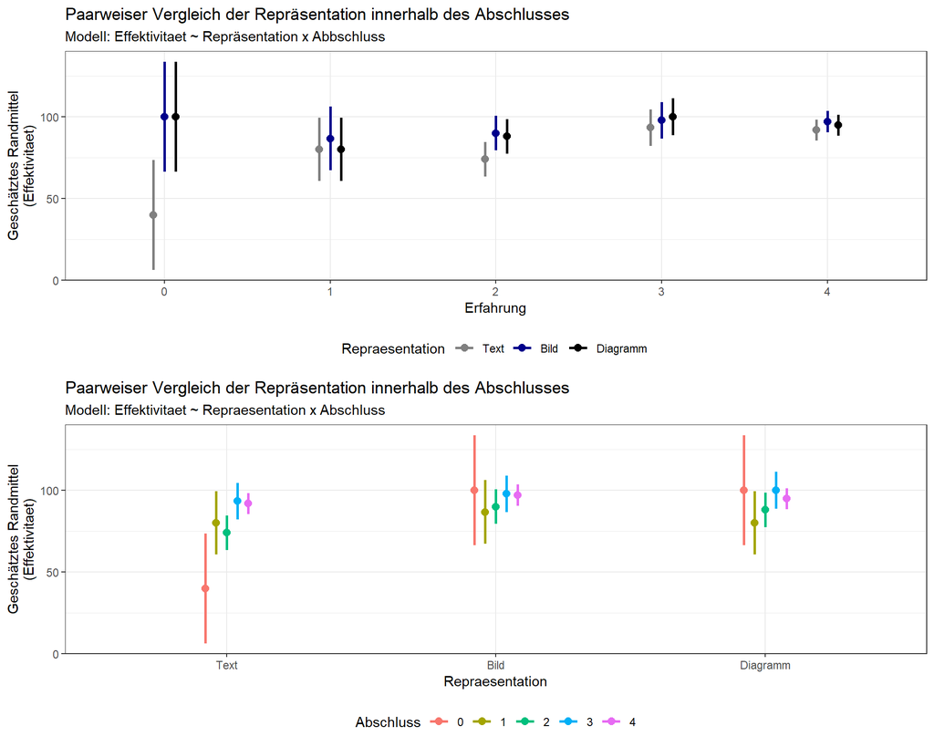

```r
representation_order <- c("Text", "Bild", "Diagramm")

plot_grid(
  emmeans(effekti_1c, specs = pairwise ~ Repraesentation * Abschluss)$emmeans %>% as.data.frame() %>%
    mutate(Repraesentation = factor(Repraesentation, levels = representation_order)) %>%
    ggplot(., aes(x = Abschluss, y = emmean, color = Repraesentation)) +
    geom_point(position = position_dodge(width = .2),
               size = 2.5) +
    geom_errorbar(aes(ymin = lower.CL, ymax = upper.CL),
                  width = 0, position = position_dodge(width = .2),
                  size = 1) +
    scale_color_manual(values = c("Text" = "#808080", "Bild" = "#00008B", "Diagramm" = "#000000")) +
    theme_bw() +
    theme(legend.position = "bottom") +
    labs(x = "Erfahrung",
         y = "Geschätztes Randmittel\n(Effektivitaet)",
         title = "Paarweiser Vergleich der Repräsentation innerhalb des Abschlusses",
         subtitle = "Modell: Effektivitaet ~ Repräsentation x Abbschluss"),

   emmeans(effekti_1c, specs = pairwise ~ Repraesentation * Abschluss)$emmeans %>% as.data.frame() %>%
    mutate(Repraesentation = factor(Repraesentation, levels = representation_order)) %>%
    ggplot(., aes(x = Repraesentation, y = emmean, color = Abschluss)) +
    geom_point(position = position_dodge(width = .2),
               size = 2.5) +
    geom_errorbar(aes(ymin = lower.CL, ymax = upper.CL),
                  width = 0, position = position_dodge(width = .2),
                  size = 1) +
    theme_bw() +
    theme(legend.position = "bottom") +
    labs(x = "Repraesentation",
         y = "Geschätztes Randmittel\n(Effektivitaet)",
         title = "Paarweiser Vergleich der Repräsentation innerhalb des Abschlusses",
         subtitle = "Modell: Effektivitaet ~ Repraesentation x Abschluss"),
  ncol = 1
)
```

*Anmerkung.* Darstellung der geschätzten Randmittel für Effektivität für die Repräsentationen getrennt nach Abschluss (oben) und einmal für den Abschluss getrennt nach Repräsentation (unten). Dargestellt werden Mittelwert mit dem 95%-Konfidenzintervall als Fehlerbalken.

###### Repraesentation nach Abschluss

```r
emmeans(effekti_1c, specs = pairwise ~ Repraesentation | Abschluss)
```

```
## $emmeans
## Abschluss = 0:
##  Repraesentation emmean    SE  df lower.CL upper.CL
##  Bild             100.0 17.01 134    66.36    133.6
##  Diagramm         100.0 17.01 134    66.36    133.6
##  Text              40.0 17.01 134     6.36     73.6
##
## Abschluss = 1:
##  Repraesentation emmean    SE  df lower.CL upper.CL
##  Bild              86.7  9.82 134    67.24    106.1
##  Diagramm          80.0  9.82 134    60.58     99.4
##  Text              80.0  9.82 134    60.58     99.4
##
## Abschluss = 2:
##  Repraesentation emmean    SE  df lower.CL upper.CL
##  Bild              90.0  5.38 134    79.36    100.6
##  Diagramm          88.0  5.38 134    77.36     98.6
##  Text              74.0  5.38 134    63.36     84.6
##
## Abschluss = 3:
##  Repraesentation emmean    SE  df lower.CL upper.CL
##  Bild              97.8  5.67 134    86.56    109.0
##  Diagramm         100.0  5.67 134    88.79    111.2
##  Text              93.3  5.67 134    82.12    104.5
##
## Abschluss = 4:
##  Repraesentation emmean    SE  df lower.CL upper.CL
##  Bild              97.0  3.27 134    90.56    103.5
##  Diagramm          94.8  3.27 134    88.34    101.3
##  Text              91.9  3.27 134    85.38     98.3
##
## Degrees-of-freedom method: kenward-roger
## Confidence level used: 0.95
##
## $contrasts
## Abschluss = 0:
##  contrast        estimate    SE df t.ratio p.value
##  Bild - Diagramm     0.00 23.45 90   0.000  1.0000
##  Bild - Text        60.00 23.45 90   2.558  0.0324
##  Diagramm - Text    60.00 23.45 90   2.558  0.0324
```

[output cut: 12 more lines]

```
##
## Abschluss = 3:
##  contrast        estimate    SE df t.ratio p.value
##  Bild - Diagramm    -2.22  7.82 90  -0.284  0.9565
##  Bild - Text         4.44  7.82 90   0.569  0.8372
##  Diagramm - Text     6.67  7.82 90   0.853  0.6713
##
## Abschluss = 4:
##  contrast        estimate    SE df t.ratio p.value
##  Bild - Diagramm     2.22  4.51 90   0.492  0.8751
##  Bild - Text         5.19  4.51 90   1.149  0.4868
##  Diagramm - Text     2.96  4.51 90   0.656  0.7892
##
## Degrees-of-freedom method: kenward-roger
## P value adjustment: tukey method for comparing a family of 3 estimates
```

###### Abschluss nach Repraesentation

```r
emmeans(effekti_1c, specs = pairwise ~ Abschluss | Repraesentation)
```

```
## $emmeans
## Repraesentation = Bild:
##  Abschluss emmean    SE  df lower.CL upper.CL
##  0          100.0 17.01 134    66.36    133.6
##  1           86.7  9.82 134    67.24    106.1
##  2           90.0  5.38 134    79.36    100.6
##  3           97.8  5.67 134    86.56    109.0
##  4           97.0  3.27 134    90.56    103.5
##
## Repraesentation = Diagramm:
##  Abschluss emmean    SE  df lower.CL upper.CL
##  0          100.0 17.01 134    66.36    133.6
##  1           80.0  9.82 134    60.58     99.4
##  2           88.0  5.38 134    77.36     98.6
##  3          100.0  5.67 134    88.79    111.2
##  4           94.8  3.27 134    88.34    101.3
##
## Repraesentation = Text:
##  Abschluss emmean    SE  df lower.CL upper.CL
##  0           40.0 17.01 134     6.36     73.6
##  1           80.0  9.82 134    60.58     99.4
##  2           74.0  5.38 134    63.36     84.6
##  3           93.3  5.67 134    82.12    104.5
##  4           91.9  3.27 134    85.38     98.3
##
## Degrees-of-freedom method: kenward-roger
## Confidence level used: 0.95
##
## $contrasts
## Repraesentation = Bild:
##  contrast                estimate    SE  df t.ratio p.value
##  Abschluss0 - Abschluss1   13.333 19.64 134   0.679  0.9607
##  Abschluss0 - Abschluss2   10.000 17.84 134   0.560  0.9804
##  Abschluss0 - Abschluss3    2.222 17.93 134   0.124  0.9999
##  Abschluss0 - Abschluss4    2.963 17.32 134   0.171  0.9998
##  Abschluss1 - Abschluss2   -3.333 11.20 134  -0.298  0.9983
##  Abschluss1 - Abschluss3  -11.111 11.34 134  -0.980  0.8640
##  Abschluss1 - Abschluss4  -10.370 10.35 134  -1.002  0.8542
##  Abschluss2 - Abschluss3   -7.778  7.82 134  -0.995  0.8572
##  Abschluss2 - Abschluss4   -7.037  6.30 134  -1.117  0.7971
```

[output cut: 15 more lines]

```
## Repraesentation = Text:
##  contrast                estimate    SE  df t.ratio p.value
##  Abschluss0 - Abschluss1  -40.000 19.64 134  -2.036  0.2545
##  Abschluss0 - Abschluss2  -34.000 17.84 134  -1.906  0.3194
##  Abschluss0 - Abschluss3  -53.333 17.93 134  -2.974  0.0283
##  Abschluss0 - Abschluss4  -51.852 17.32 134  -2.993  0.0268
##  Abschluss1 - Abschluss2    6.000 11.20 134   0.536  0.9835
##  Abschluss1 - Abschluss3  -13.333 11.34 134  -1.176  0.7652
##  Abschluss1 - Abschluss4  -11.852 10.35 134  -1.145  0.7824
##  Abschluss2 - Abschluss3  -19.333  7.82 134  -2.474  0.1029
##  Abschluss2 - Abschluss4  -17.852  6.30 134  -2.835  0.0415
##  Abschluss3 - Abschluss4    1.481  6.55 134   0.226  0.9994
##
## Degrees-of-freedom method: kenward-roger
## P value adjustment: tukey method for comparing a family of 5 estimates
```

###### nur für Abschluss

```r
emmeans(effekti_1c, specs = pairwise ~ Abschluss)
```

```
## NOTE: Results may be misleading due to involvement in interactions
```

```
## $emmeans
##  Abschluss emmean    SE df lower.CL upper.CL
##  0           80.0 10.30 45     59.3    100.7
##  1           82.2  5.95 45     70.2     94.2
##  2           84.0  3.26 45     77.4     90.6
##  3           97.0  3.43 45     90.1    104.0
##  4           94.6  1.98 45     90.6     98.6
##
## Results are averaged over the levels of: Repraesentation
## Degrees-of-freedom method: kenward-roger
## Confidence level used: 0.95
##
## $contrasts
##  contrast                estimate    SE df t.ratio p.value
##  Abschluss0 - Abschluss1    -2.22 11.89 45  -0.187  0.9997
##  Abschluss0 - Abschluss2    -4.00 10.80 45  -0.370  0.9958
##  Abschluss0 - Abschluss3   -17.04 10.85 45  -1.570  0.5241
##  Abschluss0 - Abschluss4   -14.57 10.49 45  -1.389  0.6376
##  Abschluss1 - Abschluss2    -1.78  6.78 45  -0.262  0.9989
##  Abschluss1 - Abschluss3   -14.81  6.86 45  -2.158  0.2144
##  Abschluss1 - Abschluss4   -12.35  6.27 45  -1.970  0.2970
##  Abschluss2 - Abschluss3   -13.04  4.73 45  -2.755  0.0613
##  Abschluss2 - Abschluss4   -10.57  3.81 45  -2.772  0.0589
##  Abschluss3 - Abschluss4     2.47  3.96 45   0.623  0.9706
##
## Results are averaged over the levels of: Repraesentation
## Degrees-of-freedom method: kenward-roger
## P value adjustment: tukey method for comparing a family of 5 estimates
```

#### 2)

Ergebnis:

- Signifikanter Interaktionseffekt zwischen der Aufgabenstellung und der Repräsentation für die Effektivität.
- Signifikanter Haupteffekt für die Aufgabenstellung, die *Platzierungsaufgabe* zeigt signifikant geringere Werte als die *Sortieraufgabe* auf.
- Bei der texuellen Aufgabenannotation wies die *Sortieraufgabe* signifikant höhere Effektivität auf als die *Platzierungsaufgabe*- oder die *Stapelaufgabe*.

Anteil erklärter Varianz (R²):

- Gesamtmodell: 0.161
- Haupteffektmodell ohne Interaktionen: 0.091
- Hinzunahme von Abschluss: 0.05
- Hinzunahme Interaktion im Vergleich zum Haupteffektmodell: 0.07058

##### Modelle

###### Haupteffektmodell

```r
anova(.effekti_2)
```

```
## Type III Analysis of Variance Table with Satterthwaite's method
##                  Sum Sq Mean Sq NumDF  DenDF F value  Pr(>F)
## Repraesentation  1968.3  984.15     2 96.005  3.8106 0.02556 *
## Aufgabenstellung 2479.2 1239.62     2 96.848  4.7997 0.01029 *
## ---
## Signif. codes:  0 '***' 0.001 '**' 0.01 '*' 0.05 '.' 0.1 ' ' 1
```

###### Gesamtmodell

```r
anova(effekti_2)
```

```
## Type III Analysis of Variance Table with Satterthwaite's method
##                                  Sum Sq Mean Sq NumDF   DenDF F value  Pr(>F)
## Repraesentation                  1809.9  904.94     2  94.146  3.6866 0.02874
## Aufgabenstellung                 2502.0 1250.99     2  94.983  5.0963 0.00790
## Repraesentation:Aufgabenstellung 3111.1  777.78     4 124.306  3.1685 0.01617
##
## Repraesentation                  *
## Aufgabenstellung                 **
## Repraesentation:Aufgabenstellung *
## ---
## Signif. codes:  0 '***' 0.001 '**' 0.01 '*' 0.05 '.' 0.1 ' ' 1
```

##### Paarweiser Vergleich

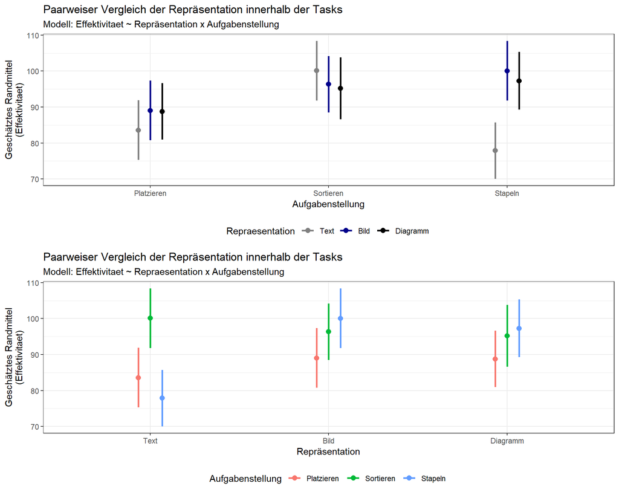

```r
representation_order <- c("Text", "Bild", "Diagramm")

plot_grid(
  emmeans(effekti_2, specs = pairwise ~ Repraesentation * Aufgabenstellung)$emmeans %>% as.data.frame() %>%
    mutate(Repraesentation = factor(Repraesentation, levels = representation_order)) %>%
    ggplot(., aes(x = Aufgabenstellung, y = emmean, color = Repraesentation)) +
    geom_point(position = position_dodge(width = .2),
               size = 2.5) +
    geom_errorbar(aes(ymin = lower.CL, ymax = upper.CL),
                  width = 0, position = position_dodge(width = .2),
                  size = 1) +
    scale_color_manual(values = c("Text" = "#808080", "Bild" = "#00008B", "Diagramm" = "#000000")) +
    theme_bw() +
    theme(legend.position = "bottom") +
    labs(x = "Aufgabenstellung",
         y = "Geschätztes Randmittel\n(Effektivitaet)",
         title = "Paarweiser Vergleich der Repräsentation innerhalb der Tasks",
         subtitle = "Modell: Effektivitaet ~ Repräsentation x Aufgabenstellung"),

  emmeans(effekti_2, specs = pairwise ~ Repraesentation * Aufgabenstellung)$emmeans %>% as.data.frame() %>%
    mutate(Repraesentation = factor(Repraesentation, levels = representation_order)) %>%
    ggplot(., aes(x = Repraesentation, y = emmean, color = Aufgabenstellung)) +
    geom_point(position = position_dodge(width = .2),
               size = 2.5) +
    geom_errorbar(aes(ymin = lower.CL, ymax = upper.CL),
                  width = 0, position = position_dodge(width = .2),
                  size = 1) +
    theme_bw() +
    theme(legend.position = "bottom") +
    labs(x = "Repräsentation",
         y = "Geschätztes Randmittel\n(Effektivitaet)",
         title = "Paarweiser Vergleich der Repräsentation innerhalb der Tasks",
         subtitle = "Modell: Effektivitaet ~ Repraesentation x Aufgabenstellung"),
  ncol = 1
)
```

###### Repraesentation nach Aufgabenstellung

```r
emmeans(effekti_2, specs = pairwise ~ Repraesentation | Aufgabenstellung)
```

```
## $emmeans
## Aufgabenstellung = Platzieren:
##  Repraesentation emmean   SE  df lower.CL upper.CL
##  Bild              89.0 4.20 141     80.7     97.4
##  Diagramm          88.8 3.96 141     80.9     96.6
##  Text              83.6 4.20 141     75.3     91.9
##
## Aufgabenstellung = Sortieren:
##  Repraesentation emmean   SE  df lower.CL upper.CL
##  Bild              96.3 3.96 141     88.5    104.2
##  Diagramm          95.2 4.34 141     86.6    103.8
##  Text             100.1 4.20 141     91.8    108.4
##
## Aufgabenstellung = Stapeln:
##  Repraesentation emmean   SE  df lower.CL upper.CL
##  Bild             100.1 4.20 141     91.8    108.4
##  Diagramm          97.3 4.08 141     89.2    105.4
##  Text              77.9 3.96 141     70.0     85.7
##
## Degrees-of-freedom method: kenward-roger
## Confidence level used: 0.95
##
## $contrasts
## Aufgabenstellung = Platzieren:
##  contrast        estimate   SE  df t.ratio p.value
##  Bild - Diagramm    0.269 5.78 141   0.047  0.9988
##  Bild - Text        5.473 5.94 141   0.921  0.6278
##  Diagramm - Text    5.205 5.77 141   0.901  0.6403
##
## Aufgabenstellung = Sortieren:
##  contrast        estimate   SE  df t.ratio p.value
##  Bild - Diagramm    1.152 5.88 141   0.196  0.9790
##  Bild - Text       -3.738 5.77 141  -0.647  0.7942
##  Diagramm - Text   -4.890 6.04 141  -0.810  0.6977
##
## Aufgabenstellung = Stapeln:
##  contrast        estimate   SE  df t.ratio p.value
##  Bild - Diagramm    2.765 5.85 141   0.472  0.8844
##  Bild - Text       22.204 5.75 140   3.861  0.0005
##  Diagramm - Text   19.439 5.68 141   3.420  0.0024
##
## Degrees-of-freedom method: kenward-roger
## P value adjustment: tukey method for comparing a family of 3 estimates
```

###### Aufgabenstellung nach Repraesentation

```r
emmeans(effekti_2, specs = pairwise ~ Aufgabenstellung | Repraesentation)
```

```
## $emmeans
## Repraesentation = Bild:
##  Aufgabenstellung emmean   SE  df lower.CL upper.CL
##  Platzieren         89.0 4.20 141     80.7     97.4
##  Sortieren          96.3 3.96 141     88.5    104.2
##  Stapeln           100.1 4.20 141     91.8    108.4
##
## Repraesentation = Diagramm:
##  Aufgabenstellung emmean   SE  df lower.CL upper.CL
##  Platzieren         88.8 3.96 141     80.9     96.6
##  Sortieren          95.2 4.34 141     86.6    103.8
##  Stapeln            97.3 4.08 141     89.2    105.4
##
## Repraesentation = Text:
##  Aufgabenstellung emmean   SE  df lower.CL upper.CL
##  Platzieren         83.6 4.20 141     75.3     91.9
##  Sortieren         100.1 4.20 141     91.8    108.4
##  Stapeln            77.9 3.96 141     70.0     85.7
##
## Degrees-of-freedom method: kenward-roger
## Confidence level used: 0.95
##
## $contrasts
## Repraesentation = Bild:
##  contrast               estimate   SE  df t.ratio p.value
##  Platzieren - Sortieren    -7.30 5.77 141  -1.264  0.4180
##  Platzieren - Stapeln     -11.01 5.94 141  -1.854  0.1561
##  Sortieren - Stapeln       -3.72 5.77 140  -0.644  0.7962
##
## Repraesentation = Diagramm:
##  contrast               estimate   SE  df t.ratio p.value
##  Platzieren - Sortieren    -6.41 5.88 141  -1.092  0.5207
##  Platzieren - Stapeln      -8.52 5.68 141  -1.498  0.2948
##  Sortieren - Stapeln       -2.10 5.95 141  -0.353  0.9335
##
## Repraesentation = Text:
##  contrast               estimate   SE  df t.ratio p.value
##  Platzieren - Sortieren   -16.51 5.94 141  -2.779  0.0170
##  Platzieren - Stapeln       5.72 5.77 141   0.990  0.5844
##  Sortieren - Stapeln       22.23 5.77 141   3.849  0.0005
##
## Degrees-of-freedom method: kenward-roger
## P value adjustment: tukey method for comparing a family of 3 estimates
```

###### nur Aufgabenstellung

```r
emmeans(effekti_2, specs = pairwise ~ Aufgabenstellung)
```

```
## NOTE: Results may be misleading due to involvement in interactions
```

```
## $emmeans
##  Aufgabenstellung emmean   SE  df lower.CL upper.CL
##  Platzieren         87.1 2.38 136     82.4     91.8
##  Sortieren          97.2 2.41 137     92.4    102.0
##  Stapeln            91.7 2.36 135     87.1     96.4
##
## Results are averaged over the levels of: Repraesentation
## Degrees-of-freedom method: kenward-roger
## Confidence level used: 0.95
##
## $contrasts
##  contrast               estimate   SE   df t.ratio p.value
##  Platzieren - Sortieren   -10.07 3.16 93.4  -3.189  0.0055
##  Platzieren - Stapeln      -4.61 3.13 93.5  -1.474  0.3082
##  Sortieren - Stapeln        5.47 3.15 94.8   1.736  0.1971
##
## Results are averaged over the levels of: Repraesentation
## Degrees-of-freedom method: kenward-roger
## P value adjustment: tukey method for comparing a family of 3 estimates
```

## Mentale Anstrengung

### Modellspezifikationen

```r
# Basismodell (Frage 1a)
beansp_1a <- lmer(Mentale_Anstrengung ~ Repraesentation + (1 | FBNUMMER), data = df)
# mit Experten (Fragestellung 1b)
.beansp_1b <- lmer(Mentale_Anstrengung ~ Repraesentation + Erfahrung + (1 | FBNUMMER), data = df)
beansp_1b <- lmer(Mentale_Anstrengung ~ Repraesentation * Erfahrung + (1 | FBNUMMER), data = df)
# mit Abschluss (Fragestellung 1c)
.beansp_1c <- lmer(Mentale_Anstrengung ~ Repraesentation + Abschluss + (1 | FBNUMMER), data = df)
beansp_1c <- lmer(Mentale_Anstrengung ~ Repraesentation * Abschluss + (1 | FBNUMMER), data = df)
# mit Aufgabenstellung (Fragestellung 2)
.beansp_2 <- lmer(Mentale_Anstrengung ~ Repraesentation + Aufgabenstellung + (1 | FBNUMMER), data = df)
beansp_2 <- lmer(Mentale_Anstrengung ~ Repraesentation * Aufgabenstellung + (1 | FBNUMMER), data = df)
# mit Aufgabenstellung & Experten (Fragestellung 2b)
# .beansp_2b <- lmer(Mentale_Anstrengung ~ Repraesentation * Aufgabenstellung + Erfahrung + (1 | FBNUMMER), data = df)
# beansp_2b <- lmer(Mentale_Anstrengung ~ Repraesentation * Aufgabenstellung * Erfahrung + (1 | FBNUMMER), data = df)
# mit Aufgabenstellung & Abschluss (Fragestellung 2c)
# .beansp_2c <- lmer(Mentale_Anstrengung ~ Repraesentation * Aufgabenstellung + Abschluss + (1 | FBNUMMER), data = df)
# beansp_2c <- lmer(Mentale_Anstrengung ~ Repraesentation * Aufgabenstellung * Abschluss + (1 | FBNUMMER), data = df)

# erklärte Varianzen
r2_1a <- MuMIn::r.squaredGLMM(beansp_1a)[[1]]
.r2_1b <- MuMIn::r.squaredGLMM(.beansp_1b)[[1]]
r2_1b <- MuMIn::r.squaredGLMM(beansp_1b)[[1]]
.r2_1c <- MuMIn::r.squaredGLMM(.beansp_1c)[[1]]
r2_1c <- MuMIn::r.squaredGLMM(beansp_1c)[[1]]
.r2_2 <- MuMIn::r.squaredGLMM(.beansp_2)[[1]]
r2_2 <- MuMIn::r.squaredGLMM(beansp_2)[[1]]
#.r2_2b <- MuMIn::r.squaredGLMM(.beansp_2b)[[1]]
#r2_2b <- MuMIn::r.squaredGLMM(beansp_2b)[[1]]
#.r2_2c <- MuMIn::r.squaredGLMM(.beansp_2c)[[1]]
#r2_2c <- MuMIn::r.squaredGLMM(beansp_2c)[[1]]
```

### Outputs

#### 1a)

Ergebnis:

- Signifikanter Zusammenhang zwischen der Mentalen Anstrengung und der Repräsentation.
- Textuelle Annotation hat signifikant höhere Mentale Anstrengung als die anderen beiden Repräsentationen. Diagramm- und Bildannotationen selbst unterscheiden sich nicht signifikant voneinander.

Anteil erklärter Varianz (R²):

- Basismodell: 0.046

##### Basismodell

```r
anova(beansp_1a)
```

```
## Type III Analysis of Variance Table with Satterthwaite's method
##                 Sum Sq Mean Sq NumDF DenDF F value   Pr(>F)
## Repraesentation 6087.7  3043.9     2    98  5.4779 0.005557 **
## ---
## Signif. codes:  0 '***' 0.001 '**' 0.01 '*' 0.05 '.' 0.1 ' ' 1
```

##### Paarweiser Vergleich

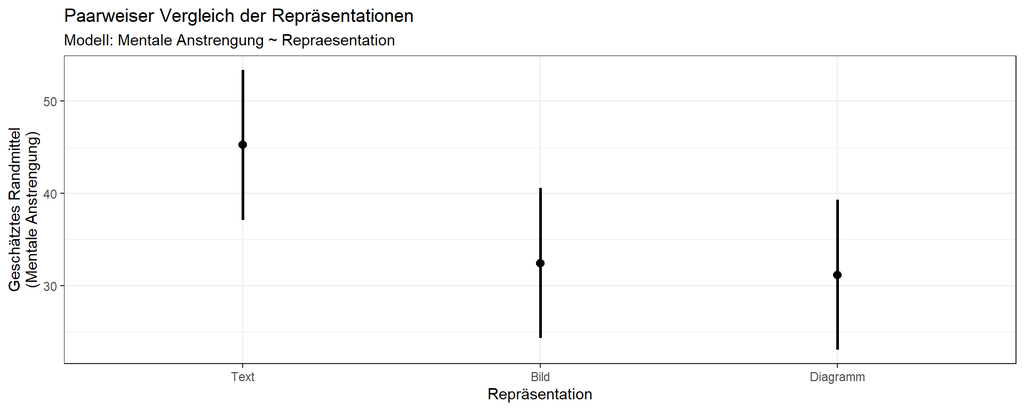

```r
representation_order <- c("Text", "Bild", "Diagramm")
emmeans(beansp_1a, specs = pairwise ~ Repraesentation)$emmeans %>% as.data.frame() %>%
    mutate(Repraesentation = factor(Repraesentation, levels = representation_order)) %>%
    ggplot(., aes(x = Repraesentation, y = emmean)) +
    geom_point(position = position_dodge(width = .2),
               size = 2.5) +
    geom_errorbar(aes(ymin = lower.CL, ymax = upper.CL),
                  width = 0, position = position_dodge(width = .2),
                  size = 1) +
    scale_color_manual(values = c("Text" = "#808080", "Bild" = "#00008B", "Diagramm" = "#000000")) +
    theme_bw() +
    theme(legend.position = "bottom") +
    labs(x = "Repräsentation",
         y = "Geschätztes Randmittel\n(Mentale Anstrengung)",
         title = "Paarweiser Vergleich der Repräsentationen",
         subtitle = "Modell: Mentale Anstrengung ~ Repraesentation")
```

*Anmerkung.* Darstellung der geschätzten Randmittel von Mentaler Anstrengung für jede Repräsentationen. Dargestellt werden Mittelwert mit dem 95%-Konfidenzintervall als Fehlerbalken.

```r
emmeans(beansp_1a, specs = pairwise ~ Repraesentation)
```

```
## $emmeans
##  Repraesentation emmean   SE  df lower.CL upper.CL
##  Bild              32.4 4.12 119     24.3     40.6
##  Diagramm          31.2 4.12 119     23.0     39.3
##  Text              45.3 4.12 119     37.1     53.4
##
## Degrees-of-freedom method: kenward-roger
## Confidence level used: 0.95
##
## $contrasts
##  contrast        estimate   SE df t.ratio p.value
##  Bild - Diagramm     1.26 4.71 98   0.267  0.9614
##  Bild - Text       -12.84 4.71 98  -2.724  0.0207
##  Diagramm - Text   -14.10 4.71 98  -2.991  0.0098
##
## Degrees-of-freedom method: kenward-roger
## P value adjustment: tukey method for comparing a family of 3 estimates
```

#### 1b)

Ergebnis:

- kein signifikanter Interaktionseffekt zwischen Erfahrung und Repräsentation für die Mentale Anstrengung.
- kein signifikanter Haupteffekt für die Erfahrung. Beansspruchung ist unabhängig von der Erfahrung.

Anteil erklärter Varianz (R²):

- Gesamtmodell: 0.049
- Haupteffektmodell ohne Interaktionen: 0.046
- Hinzunahme von Erfahrung: 0
- Hinzunahme Interaktion im Vergleich zum Haupteffektmodell: 0.00363

##### Modelle

###### Haupteffektmodell

```r
anova(.beansp_1b)
```

```
## Type III Analysis of Variance Table with Satterthwaite's method
##                 Sum Sq Mean Sq NumDF DenDF F value   Pr(>F)
## Repraesentation 6087.7 3043.86     2    98  5.4779 0.005557 **
## Erfahrung          9.1    9.05     1    48  0.0163 0.898982
## ---
## Signif. codes:  0 '***' 0.001 '**' 0.01 '*' 0.05 '.' 0.1 ' ' 1
```

###### Gesamtmodell

```r
anova(beansp_1b)
```

```
## Type III Analysis of Variance Table with Satterthwaite's method
##                           Sum Sq Mean Sq NumDF DenDF F value   Pr(>F)
## Repraesentation           6171.3 3085.67     2    96  5.4944 0.005505 **
## Erfahrung                    9.1    9.15     1    48  0.0163 0.898982
## Repraesentation:Erfahrung  541.0  270.50     2    96  0.4817 0.619244
## ---
## Signif. codes:  0 '***' 0.001 '**' 0.01 '*' 0.05 '.' 0.1 ' ' 1
```

##### Paarweiser Vergleich

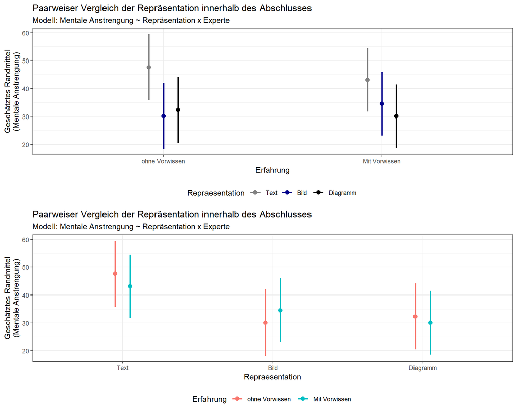

```r
representation_order <- c("Text", "Bild", "Diagramm")

plot_grid(
  emmeans(beansp_1b, specs = pairwise ~ Repraesentation * Erfahrung)$emmeans %>% as.data.frame() %>%
    mutate(Repraesentation = factor(Repraesentation, levels = representation_order)) %>%
    ggplot(., aes(x = Erfahrung, y = emmean, color = Repraesentation)) +
    geom_point(position = position_dodge(width = .2),
               size = 2.5) +
    geom_errorbar(aes(ymin = lower.CL, ymax = upper.CL),
                  width = 0, position = position_dodge(width = .2),
                  size = 1) +
    scale_color_manual(values = c("Text" = "#808080", "Bild" = "#00008B", "Diagramm" = "#000000")) +
    theme_bw() +
    theme(legend.position = "bottom") +
    labs(x = "Erfahrung",
         y = "Geschätztes Randmittel\n(Mentale Anstrengung)",
         title = "Paarweiser Vergleich der Repräsentation innerhalb des Abschlusses",
         subtitle = "Modell: Mentale Anstrengung ~ Repräsentation x Experte"),

   emmeans(beansp_1b, specs = pairwise ~ Repraesentation * Erfahrung)$emmeans %>% as.data.frame() %>%
    mutate(Repraesentation = factor(Repraesentation, levels = representation_order)) %>%
    ggplot(., aes(x = Repraesentation, y = emmean, color = Erfahrung)) +
    geom_point(position = position_dodge(width = .2),
               size = 2.5) +
    geom_errorbar(aes(ymin = lower.CL, ymax = upper.CL),
                  width = 0, position = position_dodge(width = .2),
                  size = 1) +
    theme_bw() +
    theme(legend.position = "bottom") +
    labs(x = "Repraesentation",
         y = "Geschätztes Randmittel\n(Mentale Anstrengung)",
         title = "Paarweiser Vergleich der Repräsentation innerhalb des Abschlusses",
         subtitle = "Modell: Mentale Anstrengung ~ Repräsentation x Experte"),
  ncol = 1
)
```

*Anmerkung.* Darstellung der geschätzten Randmittel von Mentaler Anstrengung für die Repräsentationen getrennt nach Erfahrung (oben) und einmal für die Erfahrung getrennt nach Repräsentation (unten). Dargestellt werden Mittelwert mit dem 95%-Konfidenzintervall als Fehlerbalken.

###### Repraesentation nach Erfahrung

```r
emmeans(beansp_1b, specs = pairwise ~ Repraesentation | Erfahrung)
```

```
## $emmeans
## Erfahrung = ohne Vorwissen:
##  Repraesentation emmean   SE  df lower.CL upper.CL
##  Bild              30.1 5.99 116     18.3     42.0
##  Diagramm          32.3 5.99 116     20.5     44.2
##  Text              47.6 5.99 116     35.8     59.5
##
## Erfahrung = Mit Vorwissen:
##  Repraesentation emmean   SE  df lower.CL upper.CL
##  Bild              34.5 5.76 116     23.1     45.9
##  Diagramm          30.1 5.76 116     18.7     41.5
##  Text              43.1 5.76 116     31.7     54.5
##
## Degrees-of-freedom method: kenward-roger
## Confidence level used: 0.95
##
## $contrasts
## Erfahrung = ohne Vorwissen:
##  contrast        estimate   SE df t.ratio p.value
##  Bild - Diagramm    -2.21 6.84 96  -0.323  0.9442
##  Bild - Text       -17.50 6.84 96  -2.558  0.0321
##  Diagramm - Text   -15.29 6.84 96  -2.235  0.0704
##
## Erfahrung = Mit Vorwissen:
##  contrast        estimate   SE df t.ratio p.value
##  Bild - Diagramm     4.46 6.57 96   0.679  0.7764
##  Bild - Text        -8.54 6.57 96  -1.299  0.3992
##  Diagramm - Text   -13.00 6.57 96  -1.978  0.1232
##
## Degrees-of-freedom method: kenward-roger
## P value adjustment: tukey method for comparing a family of 3 estimates
```

###### Erfahrung nach Repraesentation

```r
emmeans(beansp_1b, specs = pairwise ~ Erfahrung | Repraesentation)
```

```
## $emmeans
## Repraesentation = Bild:
##  Erfahrung      emmean   SE  df lower.CL upper.CL
##  ohne Vorwissen   30.1 5.99 116     18.3     42.0
##  Mit Vorwissen    34.5 5.76 116     23.1     45.9
##
## Repraesentation = Diagramm:
##  Erfahrung      emmean   SE  df lower.CL upper.CL
##  ohne Vorwissen   32.3 5.99 116     20.5     44.2
##  Mit Vorwissen    30.1 5.76 116     18.7     41.5
##
## Repraesentation = Text:
##  Erfahrung      emmean   SE  df lower.CL upper.CL
##  ohne Vorwissen   47.6 5.99 116     35.8     59.5
##  Mit Vorwissen    43.1 5.76 116     31.7     54.5
##
## Degrees-of-freedom method: kenward-roger
## Confidence level used: 0.95
##
## $contrasts
## Repraesentation = Bild:
##  contrast                       estimate   SE  df t.ratio p.value
##  ohne Vorwissen - Mit Vorwissen    -4.41 8.31 116  -0.531  0.5962
##
## Repraesentation = Diagramm:
##  contrast                       estimate   SE  df t.ratio p.value
##  ohne Vorwissen - Mit Vorwissen     2.26 8.31 116   0.272  0.7864
##
## Repraesentation = Text:
##  contrast                       estimate   SE  df t.ratio p.value
##  ohne Vorwissen - Mit Vorwissen     4.55 8.31 116   0.548  0.5851
##
## Degrees-of-freedom method: kenward-roger
```

#### 1c)

- Kein signifikanter Interaktionseffekt für den Abschluss.
- Kein signifikanter Haupteffekt für den Abschluss.

Anteil erklärter Varianz (R²):

- Gesamtmodell: 0.091
- Haupteffektmodell ohne Interaktionen: 0.064
- Hinzunahme von Abschluss: 0.018
- Hinzunahme Interaktion im Vergleich zum Haupteffektmodell: 0.02707

##### Modelle

###### Haupteffektmodell

```r
anova(.beansp_1c)
```

```
## Type III Analysis of Variance Table with Satterthwaite's method
##                 Sum Sq Mean Sq NumDF DenDF F value   Pr(>F)
## Repraesentation 6087.7 3043.86     2    98  5.4779 0.005557 **
## Abschluss       1019.8  254.96     4    45  0.4588 0.765466
## ---
## Signif. codes:  0 '***' 0.001 '**' 0.01 '*' 0.05 '.' 0.1 ' ' 1
```

###### Gesamtmodell

```r
anova(beansp_1c)
```

```
## Type III Analysis of Variance Table with Satterthwaite's method
##                           Sum Sq Mean Sq NumDF DenDF F value Pr(>F)
## Repraesentation           2484.7 1242.33     2    90  2.2228 0.1142
## Abschluss                 1025.8  256.45     4    45  0.4588 0.7655
## Repraesentation:Abschluss 4152.6  519.08     8    90  0.9287 0.4969
```

##### Paarweiser Vergleich

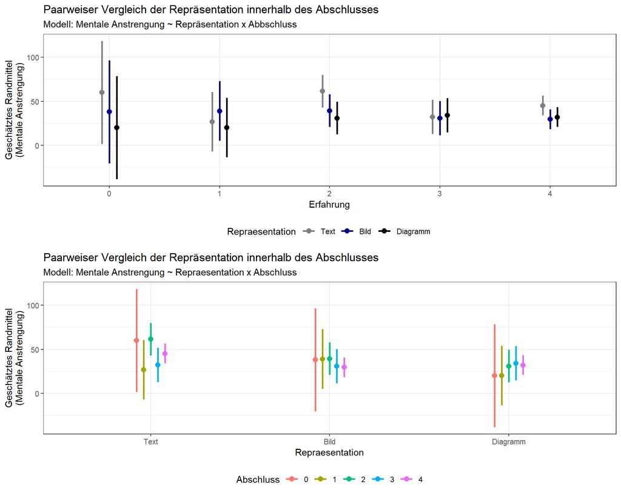

```r
representation_order <- c("Text", "Bild", "Diagramm")

plot_grid(
  emmeans(beansp_1c, specs = pairwise ~ Repraesentation * Abschluss)$emmeans %>% as.data.frame() %>%
    mutate(Repraesentation = factor(Repraesentation, levels = representation_order)) %>%
    ggplot(., aes(x = Abschluss, y = emmean, color = Repraesentation)) +
    geom_point(position = position_dodge(width = .2),
               size = 2.5) +
    geom_errorbar(aes(ymin = lower.CL, ymax = upper.CL),
                  width = 0, position = position_dodge(width = .2),
                  size = 1) +
    scale_color_manual(values = c("Text" = "#808080", "Bild" = "#00008B", "Diagramm" = "#000000")) +
    theme_bw() +
    theme(legend.position = "bottom") +
    labs(x = "Erfahrung",
         y = "Geschätztes Randmittel\n(Mentale Anstrengung)",
         title = "Paarweiser Vergleich der Repräsentation innerhalb des Abschlusses",
         subtitle = "Modell: Mentale Anstrengung ~ Repräsentation x Abbschluss"),

   emmeans(beansp_1c, specs = pairwise ~ Repraesentation * Abschluss)$emmeans %>% as.data.frame() %>%
    mutate(Repraesentation = factor(Repraesentation, levels = representation_order)) %>%
    ggplot(., aes(x = Repraesentation, y = emmean, color = Abschluss)) +
    geom_point(position = position_dodge(width = .2),
               size = 2.5) +
    geom_errorbar(aes(ymin = lower.CL, ymax = upper.CL),
                  width = 0, position = position_dodge(width = .2),
                  size = 1) +
    theme_bw() +
    theme(legend.position = "bottom") +
    labs(x = "Repraesentation",
         y = "Geschätztes Randmittel\n(Mentale Anstrengung)",
         title = "Paarweiser Vergleich der Repräsentation innerhalb des Abschlusses",
         subtitle = "Modell: Mentale Anstrengung ~ Repraesentation x Abschluss"),
  ncol = 1
)
```

*Anmerkung.* Darstellung der geschätzten Randmittel für Mentale Anstrengung für die Repräsentationen getrennt nach Abschluss (oben) und einmal für den Abschluss getrennt nach Repräsentation (unten). Dargestellt werden Mittelwert mit dem 95%-Konfidenzintervall als Fehlerbalken.

###### Repraesentation nach Abschluss

```r
emmeans(beansp_1c, specs = pairwise ~ Repraesentation | Abschluss)
```

```
## $emmeans
## Abschluss = 0:
##  Repraesentation emmean    SE  df lower.CL upper.CL
##  Bild              38.0 29.52 107   -20.52     96.5
##  Diagramm          20.0 29.52 107   -38.52     78.5
##  Text              60.0 29.52 107     1.48    118.5
##
## Abschluss = 1:
##  Repraesentation emmean    SE  df lower.CL upper.CL
##  Bild              39.0 17.05 107     5.21     72.8
##  Diagramm          20.0 17.05 107   -13.79     53.8
##  Text              26.7 17.05 107    -7.12     60.5
##
## Abschluss = 2:
##  Repraesentation emmean    SE  df lower.CL upper.CL
##  Bild              39.3  9.34 107    20.79     57.8
##  Diagramm          30.8  9.34 107    12.29     49.3
##  Text              61.4  9.34 107    42.89     79.9
##
## Abschluss = 3:
##  Repraesentation emmean    SE  df lower.CL upper.CL
##  Bild              30.7  9.84 107    11.16     50.2
##  Diagramm          34.1  9.84 107    14.60     53.6
##  Text              32.1  9.84 107    12.60     51.6
##
## Abschluss = 4:
##  Repraesentation emmean    SE  df lower.CL upper.CL
##  Bild              29.5  5.68 107    18.26     40.8
##  Diagramm          32.0  5.68 107    20.70     43.2
##  Text              45.2  5.68 107    33.92     56.4
##
## Degrees-of-freedom method: kenward-roger
## Confidence level used: 0.95
##
## $contrasts
## Abschluss = 0:
##  contrast        estimate    SE df t.ratio p.value
##  Bild - Diagramm    18.00 33.43 90   0.538  0.8526
##  Bild - Text       -22.00 33.43 90  -0.658  0.7883
##  Diagramm - Text   -40.00 33.43 90  -1.196  0.4584
```

[output cut: 12 more lines]

```
##
## Abschluss = 3:
##  contrast        estimate    SE df t.ratio p.value
##  Bild - Diagramm    -3.44 11.14 90  -0.309  0.9487
##  Bild - Text        -1.44 11.14 90  -0.130  0.9908
##  Diagramm - Text     2.00 11.14 90   0.179  0.9824
##
## Abschluss = 4:
##  contrast        estimate    SE df t.ratio p.value
##  Bild - Diagramm    -2.44  6.43 90  -0.380  0.9236
##  Bild - Text       -15.67  6.43 90  -2.435  0.0441
##  Diagramm - Text   -13.22  6.43 90  -2.055  0.1052
##
## Degrees-of-freedom method: kenward-roger
## P value adjustment: tukey method for comparing a family of 3 estimates
```

###### Abschluss nach Repraesentation

```r
emmeans(beansp_1c, specs = pairwise ~ Abschluss | Repraesentation)
```

```
## $emmeans
## Repraesentation = Bild:
##  Abschluss emmean    SE  df lower.CL upper.CL
##  0           38.0 29.52 107   -20.52     96.5
##  1           39.0 17.05 107     5.21     72.8
##  2           39.3  9.34 107    20.79     57.8
##  3           30.7  9.84 107    11.16     50.2
##  4           29.5  5.68 107    18.26     40.8
##
## Repraesentation = Diagramm:
##  Abschluss emmean    SE  df lower.CL upper.CL
##  0           20.0 29.52 107   -38.52     78.5
##  1           20.0 17.05 107   -13.79     53.8
##  2           30.8  9.34 107    12.29     49.3
##  3           34.1  9.84 107    14.60     53.6
##  4           32.0  5.68 107    20.70     43.2
##
## Repraesentation = Text:
##  Abschluss emmean    SE  df lower.CL upper.CL
##  0           60.0 29.52 107     1.48    118.5
##  1           26.7 17.05 107    -7.12     60.5
##  2           61.4  9.34 107    42.89     79.9
##  3           32.1  9.84 107    12.60     51.6
##  4           45.2  5.68 107    33.92     56.4
##
## Degrees-of-freedom method: kenward-roger
## Confidence level used: 0.95
##
## $contrasts
## Repraesentation = Bild:
##  contrast                estimate   SE  df t.ratio p.value
##  Abschluss0 - Abschluss1    -1.00 34.1 107  -0.029  1.0000
##  Abschluss0 - Abschluss2    -1.30 31.0 107  -0.042  1.0000
##  Abschluss0 - Abschluss3     7.33 31.1 107   0.236  0.9993
##  Abschluss0 - Abschluss4     8.48 30.1 107   0.282  0.9986
##  Abschluss1 - Abschluss2    -0.30 19.4 107  -0.015  1.0000
##  Abschluss1 - Abschluss3     8.33 19.7 107   0.423  0.9932
##  Abschluss1 - Abschluss4     9.48 18.0 107   0.528  0.9843
##  Abschluss2 - Abschluss3     8.63 13.6 107   0.636  0.9688
##  Abschluss2 - Abschluss4     9.78 10.9 107   0.895  0.8982
```

[output cut: 15 more lines]

```
## Repraesentation = Text:
##  contrast                estimate   SE  df t.ratio p.value
##  Abschluss0 - Abschluss1    33.33 34.1 107   0.978  0.8647
##  Abschluss0 - Abschluss2    -1.40 31.0 107  -0.045  1.0000
##  Abschluss0 - Abschluss3    27.89 31.1 107   0.896  0.8977
##  Abschluss0 - Abschluss4    14.81 30.1 107   0.493  0.9879
##  Abschluss1 - Abschluss2   -34.73 19.4 107  -1.787  0.3864
##  Abschluss1 - Abschluss3    -5.44 19.7 107  -0.277  0.9987
##  Abschluss1 - Abschluss4   -18.52 18.0 107  -1.031  0.8406
##  Abschluss2 - Abschluss3    29.29 13.6 107   2.159  0.2033
##  Abschluss2 - Abschluss4    16.21 10.9 107   1.484  0.5753
##  Abschluss3 - Abschluss4   -13.07 11.4 107  -1.151  0.7792
##
## Degrees-of-freedom method: kenward-roger
## P value adjustment: tukey method for comparing a family of 5 estimates
```

#### 2)

Anteil erklärter Varianz (R²):

- Gesamtmodell: 0.164
- Haupteffektmodell ohne Interaktionen: 0.115
- Hinzunahme von Abschluss: 0.069
- Hinzunahme Interaktion im Vergleich zum Haupteffektmodell: 0.04905

##### Modelle

###### Haupteffektmodell

```r
anova(.beansp_2)
```

```
## Type III Analysis of Variance Table with Satterthwaite's method
##                  Sum Sq Mean Sq NumDF DenDF F value    Pr(>F)
## Repraesentation  5865.4  2932.7     2 96.00  6.2599 0.0027834 **
## Aufgabenstellung 9237.8  4618.9     2 96.41  9.8591 0.0001271 ***
## ---
## Signif. codes:  0 '***' 0.001 '**' 0.01 '*' 0.05 '.' 0.1 ' ' 1
```

###### Gesamtmodell

```r
anova(beansp_2)
```

```
## Type III Analysis of Variance Table with Satterthwaite's method
##                                  Sum Sq Mean Sq NumDF   DenDF F value    Pr(>F)
## Repraesentation                  5403.4  2701.7     2  93.501  5.8394 0.0040767
## Aufgabenstellung                 9032.3  4516.1     2  93.949  9.7611 0.0001407
## Repraesentation:Aufgabenstellung 4354.1  1088.5     4 130.372  2.3527 0.0573219
##
## Repraesentation                  **
## Aufgabenstellung                 ***
## Repraesentation:Aufgabenstellung .
## ---
## Signif. codes:  0 '***' 0.001 '**' 0.01 '*' 0.05 '.' 0.1 ' ' 1
```

##### Paarweiser Vergleich

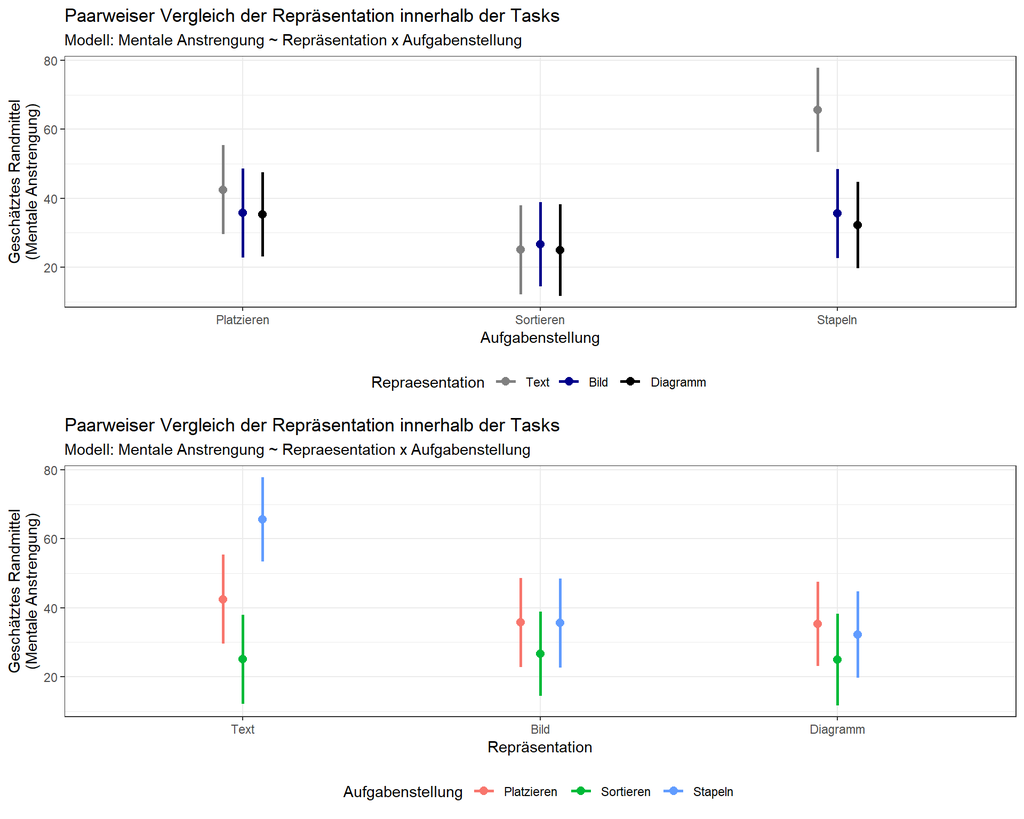

```r
representation_order <- c("Text", "Bild", "Diagramm")

plot_grid(
  emmeans(beansp_2, specs = pairwise ~ Repraesentation * Aufgabenstellung)$emmeans %>% as.data.frame() %>%
    mutate(Repraesentation = factor(Repraesentation, levels = representation_order)) %>%
    ggplot(., aes(x = Aufgabenstellung, y = emmean, color = Repraesentation)) +
    geom_point(position = position_dodge(width = .2),
               size = 2.5) +
    geom_errorbar(aes(ymin = lower.CL, ymax = upper.CL),
                  width = 0, position = position_dodge(width = .2),
                  size = 1) +
    scale_color_manual(values = c("Text" = "#808080", "Bild" = "#00008B", "Diagramm" = "#000000")) +
    theme_bw() +
    theme(legend.position = "bottom") +
    labs(x = "Aufgabenstellung",
         y = "Geschätztes Randmittel\n(Mentale Anstrengung)",
         title = "Paarweiser Vergleich der Repräsentation innerhalb der Tasks",
         subtitle = "Modell: Mentale Anstrengung ~ Repräsentation x Aufgabenstellung"),

  emmeans(beansp_2, specs = pairwise ~ Repraesentation * Aufgabenstellung)$emmeans %>% as.data.frame() %>%
    mutate(Repraesentation = factor(Repraesentation, levels = representation_order)) %>%
    ggplot(., aes(x = Repraesentation, y = emmean, color = Aufgabenstellung)) +
    geom_point(position = position_dodge(width = .2),
               size = 2.5) +
    geom_errorbar(aes(ymin = lower.CL, ymax = upper.CL),
                  width = 0, position = position_dodge(width = .2),
                  size = 1) +
    theme_bw() +
    theme(legend.position = "bottom") +
    labs(x = "Repräsentation",
         y = "Geschätztes Randmittel\n(Mentale Anstrengung)",
         title = "Paarweiser Vergleich der Repräsentation innerhalb der Tasks",
         subtitle = "Modell: Mentale Anstrengung ~ Repraesentation x Aufgabenstellung"),
  ncol = 1
)
```

###### Repraesentation nach Aufgabenstellung

```r
emmeans(beansp_2, specs = pairwise ~ Repraesentation | Aufgabenstellung)
```

```
## $emmeans
## Aufgabenstellung = Platzieren:
##  Repraesentation emmean   SE  df lower.CL upper.CL
##  Bild              35.7 6.53 140     22.8     48.7
##  Diagramm          35.3 6.18 139     23.1     47.5
##  Text              42.5 6.51 140     29.6     55.4
##
## Aufgabenstellung = Sortieren:
##  Repraesentation emmean   SE  df lower.CL upper.CL
##  Bild              26.7 6.16 140     14.5     38.9
##  Diagramm          25.0 6.72 141     11.7     38.3
##  Text              25.1 6.53 140     12.2     38.0
##
## Aufgabenstellung = Stapeln:
##  Repraesentation emmean   SE  df lower.CL upper.CL
##  Bild              35.6 6.51 140     22.7     48.4
##  Diagramm          32.2 6.35 140     19.7     44.8
##  Text              65.6 6.17 139     53.4     77.9
##
## Degrees-of-freedom method: kenward-roger
## Confidence level used: 0.95
##
## $contrasts
## Aufgabenstellung = Platzieren:
##  contrast        estimate   SE  df t.ratio p.value
##  Bild - Diagramm    0.447 8.78 138   0.051  0.9986
##  Bild - Text       -6.742 8.98 136  -0.751  0.7338
##  Diagramm - Text   -7.190 8.73 136  -0.823  0.6892
##
## Aufgabenstellung = Sortieren:
##  contrast        estimate   SE  df t.ratio p.value
##  Bild - Diagramm    1.686 8.88 136   0.190  0.9803
##  Bild - Text        1.572 8.76 137   0.180  0.9824
##  Diagramm - Text   -0.114 9.14 137  -0.013  0.9999
##
## Aufgabenstellung = Stapeln:
##  contrast        estimate   SE  df t.ratio p.value
##  Bild - Diagramm    3.335 8.85 136   0.377  0.9248
##  Bild - Text      -30.082 8.65 135  -3.477  0.0020
##  Diagramm - Text  -33.418 8.63 138  -3.873  0.0005
##
## Degrees-of-freedom method: kenward-roger
## P value adjustment: tukey method for comparing a family of 3 estimates
```

###### Aufgabenstellung nach Repraesentation

```r
emmeans(beansp_2, specs = pairwise ~ Aufgabenstellung | Repraesentation)
```

```
## $emmeans
## Repraesentation = Bild:
##  Aufgabenstellung emmean   SE  df lower.CL upper.CL
##  Platzieren         35.7 6.53 140     22.8     48.7
##  Sortieren          26.7 6.16 140     14.5     38.9
##  Stapeln            35.6 6.51 140     22.7     48.4
##
## Repraesentation = Diagramm:
##  Aufgabenstellung emmean   SE  df lower.CL upper.CL
##  Platzieren         35.3 6.18 139     23.1     47.5
##  Sortieren          25.0 6.72 141     11.7     38.3
##  Stapeln            32.2 6.35 140     19.7     44.8
##
## Repraesentation = Text:
##  Aufgabenstellung emmean   SE  df lower.CL upper.CL
##  Platzieren         42.5 6.51 140     29.6     55.4
##  Sortieren          25.1 6.53 140     12.2     38.0
##  Stapeln            65.6 6.17 139     53.4     77.9
##
## Degrees-of-freedom method: kenward-roger
## Confidence level used: 0.95
##
## $contrasts
## Repraesentation = Bild:
##  contrast               estimate   SE  df t.ratio p.value
##  Platzieren - Sortieren    9.074 8.76 137   1.036  0.5554
##  Platzieren - Stapeln      0.178 8.99 137   0.020  0.9998
##  Sortieren - Stapeln      -8.896 8.70 135  -1.022  0.5641
##
## Repraesentation = Diagramm:
##  contrast               estimate   SE  df t.ratio p.value
##  Platzieren - Sortieren   10.313 8.89 136   1.160  0.4790
##  Platzieren - Stapeln      3.065 8.63 138   0.355  0.9329
##  Sortieren - Stapeln      -7.248 9.00 136  -0.805  0.7005
##
## Repraesentation = Text:
##  contrast               estimate   SE  df t.ratio p.value
##  Platzieren - Sortieren   17.388 8.99 136   1.935  0.1328
##  Platzieren - Stapeln    -23.162 8.72 136  -2.655  0.0240
##  Sortieren - Stapeln     -40.551 8.77 138  -4.625  <.0001
##
## Degrees-of-freedom method: kenward-roger
## P value adjustment: tukey method for comparing a family of 3 estimates
```

###### nur Aufgabenstellung

```r
emmeans(beansp_2, specs = pairwise ~ Aufgabenstellung)
```

```
## NOTE: Results may be misleading due to involvement in interactions
```

```
## $emmeans
##  Aufgabenstellung emmean   SE  df lower.CL upper.CL
##  Platzieren         37.8 3.88 110     30.1     45.5
##  Sortieren          25.6 3.92 111     17.8     33.3
##  Stapeln            44.5 3.86 108     36.8     52.1
##
## Results are averaged over the levels of: Repraesentation
## Degrees-of-freedom method: kenward-roger
## Confidence level used: 0.95
##
## $contrasts
##  contrast               estimate   SE   df t.ratio p.value
##  Platzieren - Sortieren    12.26 4.34 92.7   2.825  0.0158
##  Platzieren - Stapeln      -6.64 4.29 92.8  -1.546  0.2742
##  Sortieren - Stapeln      -18.90 4.33 93.5  -4.361  0.0001
##
## Results are averaged over the levels of: Repraesentation
## Degrees-of-freedom method: kenward-roger
## P value adjustment: tukey method for comparing a family of 3 estimates
```